# Auswertung TC Daten

## 7.2 pool

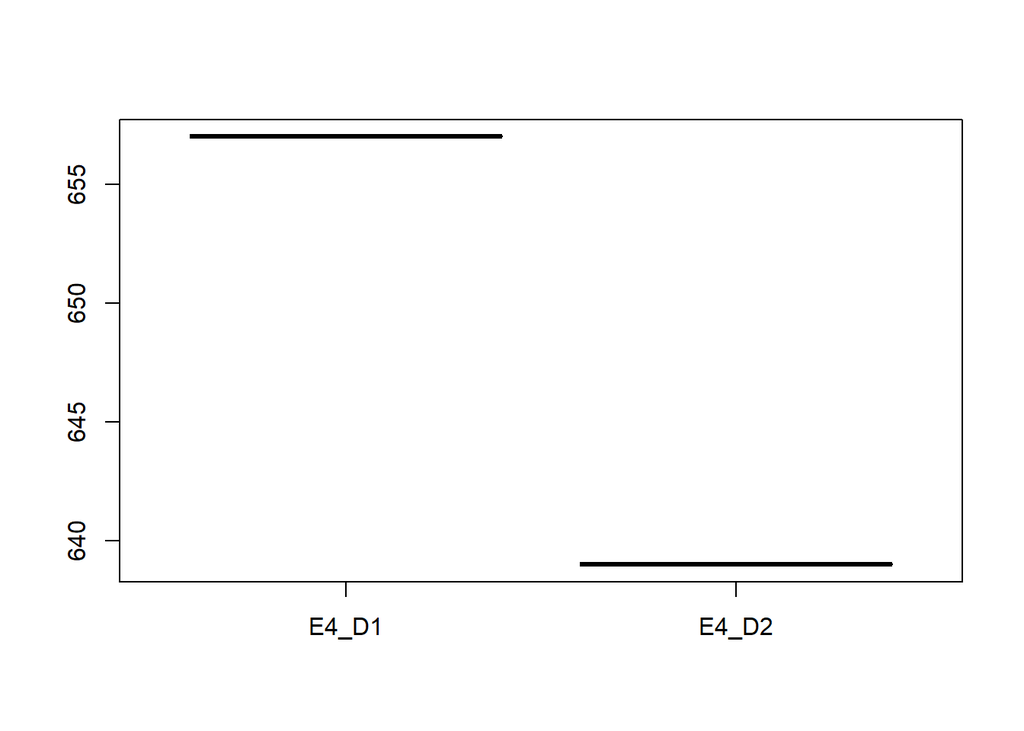

```r
# D1-D2 comparison

D1_raw <- readRDS(file = "results_v002/results_run1_mqpar_extracts_2gether_E4_D1_a-j_LFQ_combined_txt_proteinGroups.txt_Unique.RDS")
D1_raw <- D1_raw[[1]]
D1 <- dplyr::select(D1_raw, contains("Pool"))
D1 <- apply(D1, 1, any)
#D1 <- as.data.frame(cbind(D1, D1_raw$FASTA))
fasta <- c()
for (i in 1:length(D1_raw$FASTA)){
  tmp <- strsplit(D1_raw$FASTA[i],split='\\|')[[1]][2]
  fasta <- c(fasta,tmp)
}
D1 <- as.data.frame(cbind(D1, fasta))
D2_raw <- readRDS(file = "results_v002/results_run1_mqpar_extracts_2gether_D2_LFQ_combined_txt_proteinGroups.txt_Unique.RDS")
D2_raw <- D2_raw[[1]]
D2 <- dplyr::select(D2_raw, contains("Gesamt"))
D2 <- apply(D2, 1, any)
fasta <- c()
for (i in 1:length(D2_raw$FASTA)){
  tmp <- strsplit(D2_raw$FASTA[i],split='\\|')[[1]][2]
  fasta <- c(fasta,tmp)
}
#D2 <- as.data.frame(cbind(D2, D2_raw$FASTA))
D2 <- as.data.frame(cbind(D2, fasta))
D1_D2_comparison  <- merge(D1, D2,
                           all = TRUE,
                           by = "fasta")

D1_D2_comparison$D1 <- as.logical(D1_D2_comparison$D1)
D1_D2_comparison$D2 <- as.logical(D1_D2_comparison$D2)
D1_D2_comparison <- D1_D2_comparison[,-1]*1
D1_D2_comparison[D1_D2_comparison==0] <- NA

# boxplot
boxplot(sum(D1_D2_comparison$D1,na.rm = TRUE),
        sum(D1_D2_comparison$D2,na.rm = TRUE),
        names = c("E4_D1","E4_D2"))
```

```r
proteins <- as.data.frame(which(!is.na(D1_D2_comparison), arr.ind=TRUE))

D1_inter <- proteins %>% dplyr::filter(col == 1)
D2_inter <- proteins %>% dplyr::filter(col == 2)

# combine to list
lst <- list("E4_D1"=as.double(D1_inter[,1]),
            "E4_D2"=as.double(D2_inter[,1]))

upset(fromList(lst),
      order.by = "freq",
      nsets = 10,
      nintersects = 15,
      keep.order = TRUE,
      sets=c("E4_D1", "E4_D2"),
      mainbar.y.label = "Number of shared proteins",
      sets.x.label = "Number of proteins per fraction",
      set_size.show = TRUE,
      set_size.angles = 0,
      set_size.scale_max = 1000
)
```

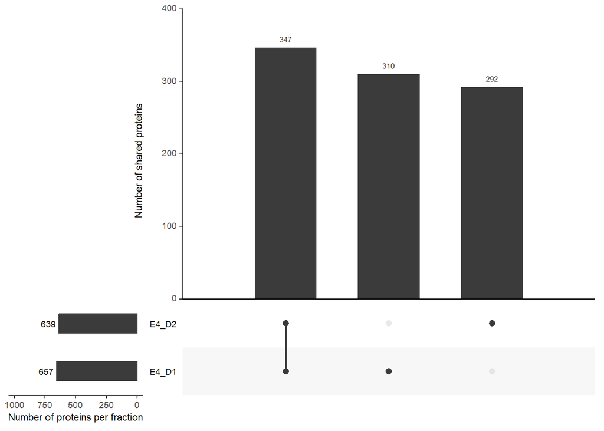

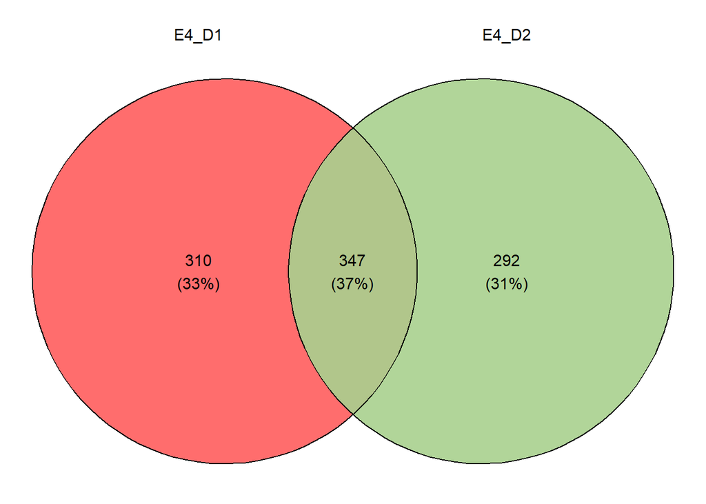

```r
#venn digarams
#get colors
D1_col <- rgb(255,93,93, maxColorValue = 255)
D2_col <- rgb(169,208,142,maxColorValue = 255)
#E4_D1_pool_col <- rgb(255,217,102, maxColorValue = 255)

ggvenn(lst,
       fill_color = c(D1_col,D2_col),
       stroke_size = 0.5, set_name_size = 4, text_size = 4, digits = 0, fill_alpha = 0.9)
```

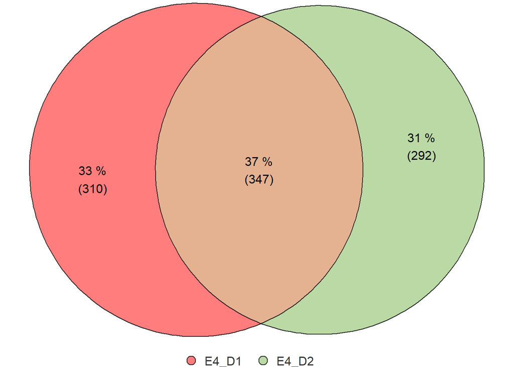

```r
euler_venn_2comp(lst, label_venn = c("E4_D1","E4_D2"), color_venn = c(D1_col,D2_col), cex_venn = c(1,1), h_just = 0.5, v_just = 0.5)
```

```r
print(c("E4_D1","E4_D2"))
```

```
## [1] "E4_D1" "E4_D2"
```

```r
sum(D1_D2_comparison$D1,na.rm = TRUE)
```

```
## [1] 657
```

```r
sum(D1_D2_comparison$D2,na.rm = TRUE)
```

```
## [1] 639
```

# 8 E5 - venn diagramms of different dimensions

- `file:///N:/1_A_Bachelor_Master_Intern/2_M_2022/David/Data/27_20230201_FH/post-processing-extracts.html#52_Summary_Unique`
- venn diagramm 1a,2a,3a,
- venn diagramm 1b,2b,3b,4b
- aussage: saurer puffer (2a,3b) bringt nichts -> citratpuffer

## 8.1 a

- E5 a weglassen weil ja auch D4 fehlt

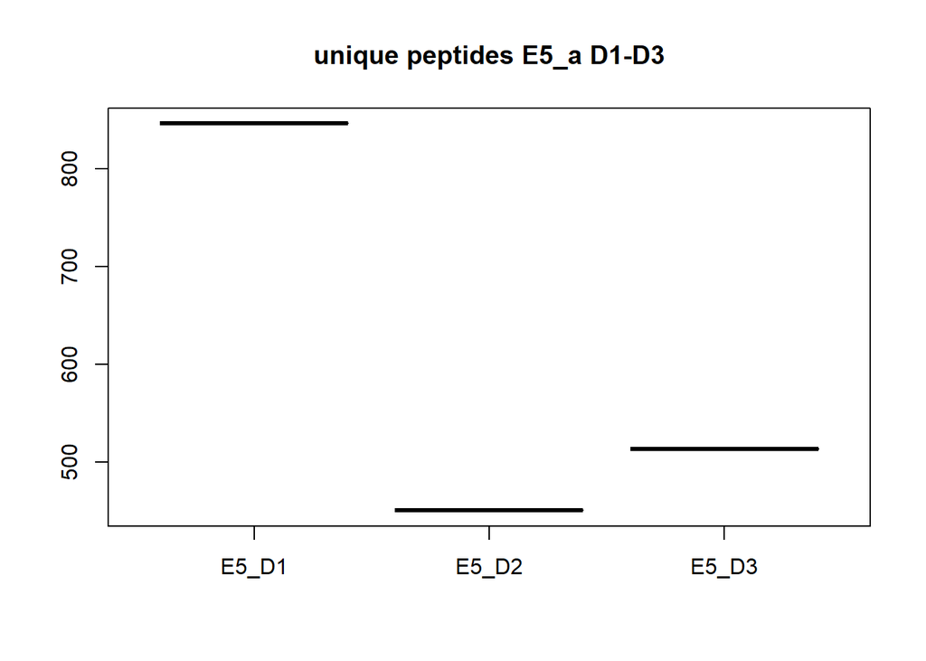

```r
data <- readRDS("./27_20230201_FH/results/D5_extracts_Razor.RDS")
data <- data[[1]]
a <- dplyr::select(data, contains("_a"))
D1_a <- a$Razor...unique.peptides.1_a_01+a$Razor...unique.peptides.1_a_02
D2_a <- a$Razor...unique.peptides.2_a_01 + a$Razor...unique.peptides.2_a_02
D3_a <- a$Razor...unique.peptides.3_a_01 + a$Razor...unique.peptides.3_a_02
a <- as.data.frame(cbind(D1_a,D2_a,D3_a))
a[a==0] <- NA
a[a==2] <- 1
boxplot(sum(a$Razor...unique.peptides.1_a_01,na.rm = TRUE),
        sum(a$Razor...unique.peptides.2_a_01,na.rm = TRUE),
        sum(a$Razor...unique.peptides.3_a_01,na.rm = TRUE),
        names = c("E5_D1","E5_D2","E5_D3"),
        main="unique peptides E5_a D1-D3")
```

```r
#venn diagram
proteins <- as.data.frame(which(!is.na(a), arr.ind=TRUE))
D1_a <- proteins %>% dplyr::filter(col == 1)
D2_a <- proteins %>% dplyr::filter(col == 2)
D3_a <- proteins %>% dplyr::filter(col == 3)

# combine to list
lst <- list(E5_D1_a = as.double(D1_a[,1]),
            E5_D2_a = as.double(D2_a[,1]),
            E5_D3_a = as.double(D3_a[,1]))
#upset r
upset(fromList(lst),
      order.by = "freq",
      nsets = 9,
      nintersects = 15,
      sets = c("E5_D1_a","E5_D2_a","E5_D3_a"),
      keep.order = TRUE,
      mainbar.y.label = "Number of shared proteins",
      sets.x.label = "Number of proteins per fraction",
      set_size.show = TRUE,
      set_size.angles = 0,
      set_size.scale_max = 1500
)
```

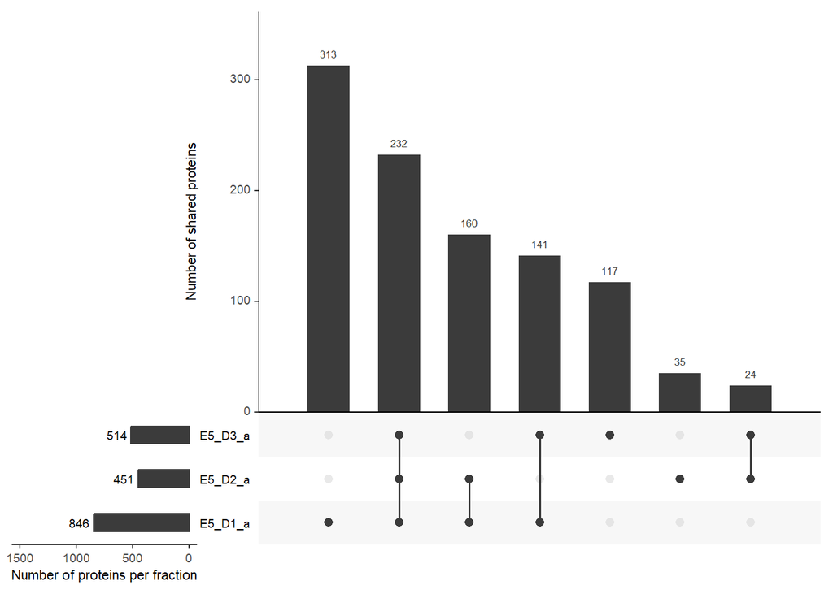

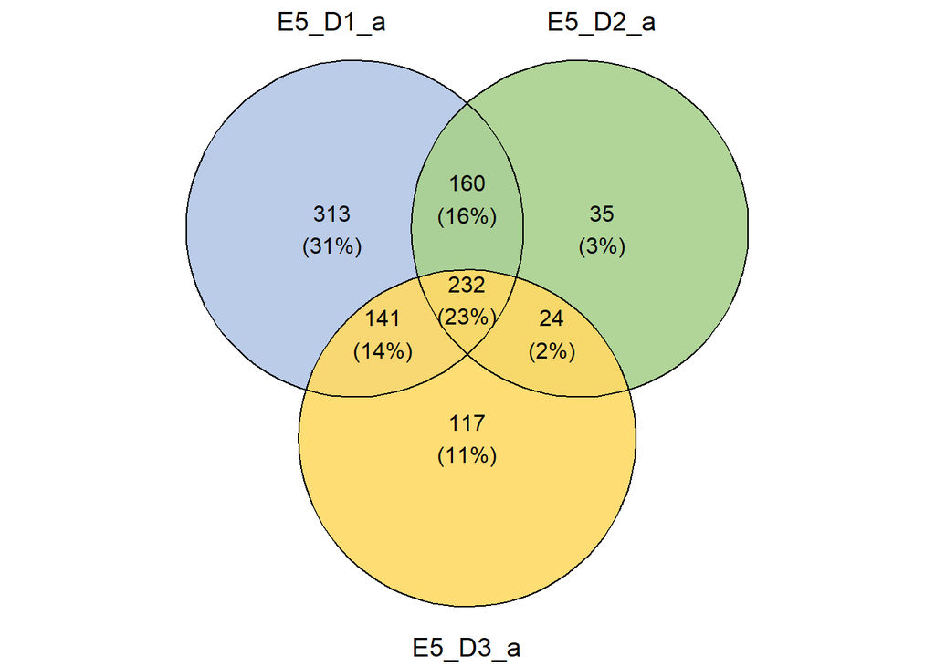

```r
# venn diagram
ggvenn(lst,
       fill_color = c(IG,highMW,lowMW),
       stroke_size = 0.5, set_name_size = 5, text_size = 4.25, digits = 0, fill_alpha = 0.9, label_sep = )
```

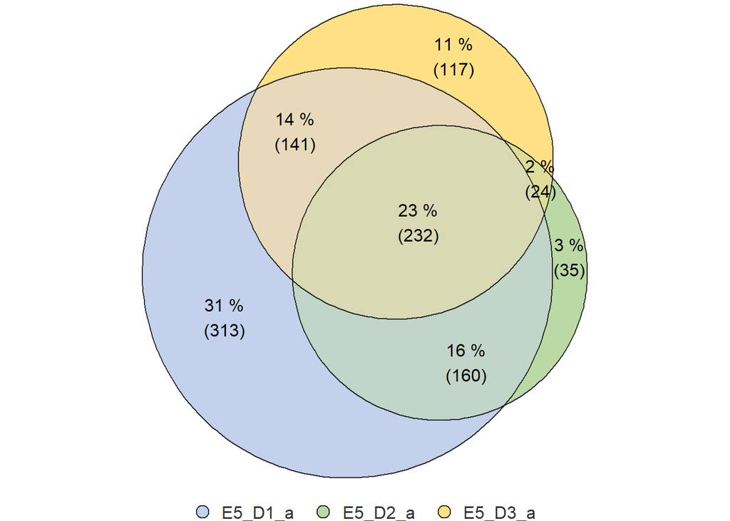

```r
euler_venn_3comp(lst, label_venn = c("E5_D1_a","E5_D2_a","E5_D3_a"), color_venn = c(IG,highMW,lowMW), cex_venn = c(1,1,1), h_just = 0.5, v_just = 0.5)
```

## 8.2 b

### 8.2.1 D1-D4

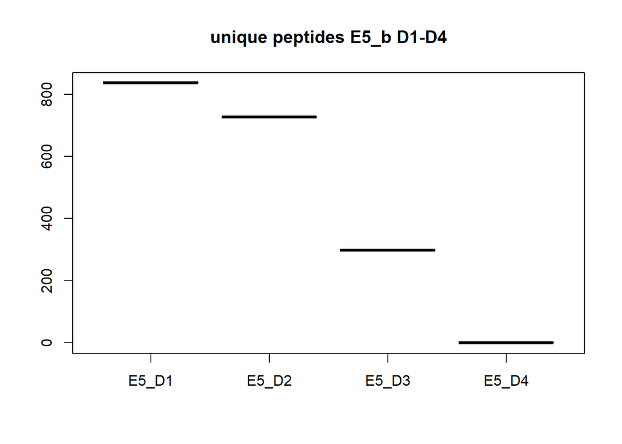

```r
data <- readRDS("./27_20230201_FH/results/D5_extracts_Razor.RDS")
data <- data[[1]]
b <- dplyr::select(data, contains("_b"))
D1_b <- b$Razor...unique.peptides.1_b_01+ b$Razor...unique.peptides.1_b_02
D2_b <- b$Razor...unique.peptides.2_b_01 + b$Razor...unique.peptides.2_b_02
D3_b <- b$Razor...unique.peptides.3_b_01 + b$Razor...unique.peptides.3_b_02
D4_b <- b$Razor...unique.peptides.3_b_01 + b$Razor...unique.peptides.4_b_02
b <- as.data.frame(cbind(D1_b,D2_b,D3_b,D4_b))
b[b==0] <- NA
b[b==2] <- 1
boxplot(sum(b$Razor...unique.peptides.1_b_01,na.rm = TRUE),
        sum(b$Razor...unique.peptides.2_b_01,na.rm = TRUE),
        sum(b$Razor...unique.peptides.3_b_01,na.rm = TRUE),
        sum(b$Razor...unique.peptides.4_b_01,na.rm = TRUE),
        names = c("E5_D1","E5_D2","E5_D3","E5_D4"),
        main="unique peptides E5_b D1-D4")
```

```r
#venn diagram
proteins <- as.data.frame(which(!is.na(b), arr.ind=TRUE))
D1_b <- proteins %>% dplyr::filter(col == 1)
D2_b <- proteins %>% dplyr::filter(col == 2)
D3_b <- proteins %>% dplyr::filter(col == 3)
D4_b <- proteins %>% dplyr::filter(col == 4)

# combine to list
lst <- list(E5_D1_b = as.double(D1_b[,1]),
            E5_D2_b = as.double(D2_b[,1]),
            E5_D3_b = as.double(D3_b[,1]),
            E5_D4_b = as.double(D4_b[,1]))
#upset r
upset(fromList(lst),
      order.by = "freq",
      nsets = 9,
      nintersects = 15,
      sets = c("E5_D1_b","E5_D2_b","E5_D3_b", "E5_D4_b"),
      keep.order = TRUE,
      mainbar.y.label = "Number of shared proteins",
      sets.x.label = "Number of proteins per fraction",
      set_size.show = TRUE,
      set_size.angles = 0,
      set_size.scale_max = 1500
)
```

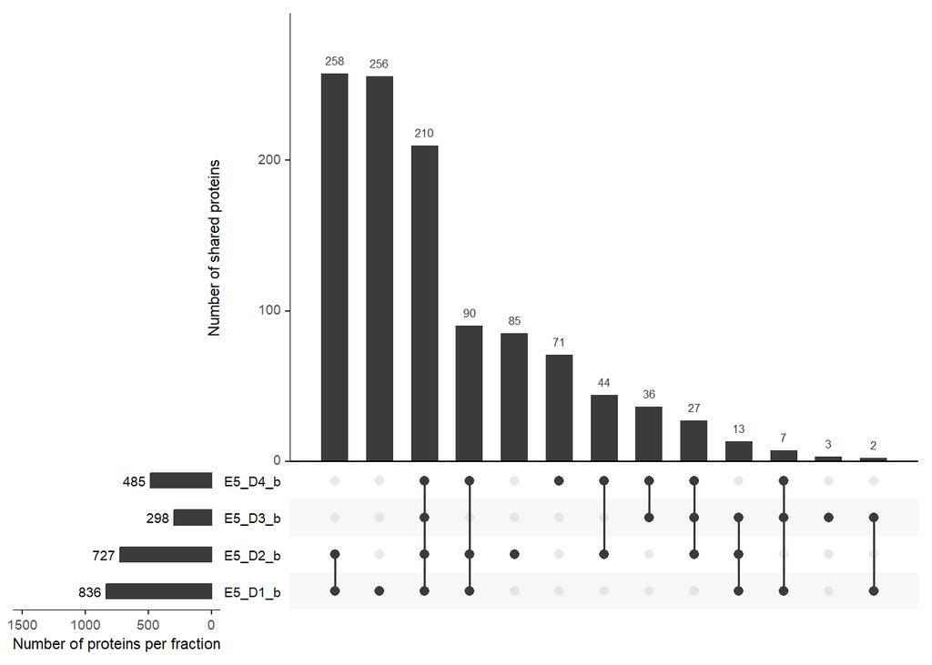

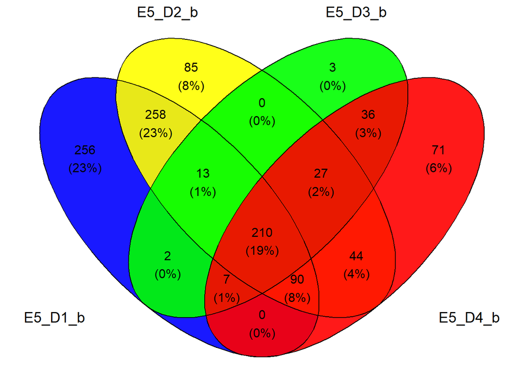

```r
# venn diagram
ggvenn(lst,
       stroke_size = 0.5, set_name_size = 5, text_size = 4.25, digits = 0, fill_alpha = 0.9, label_sep = )
```

### 8.2.2 D1,D2,D4

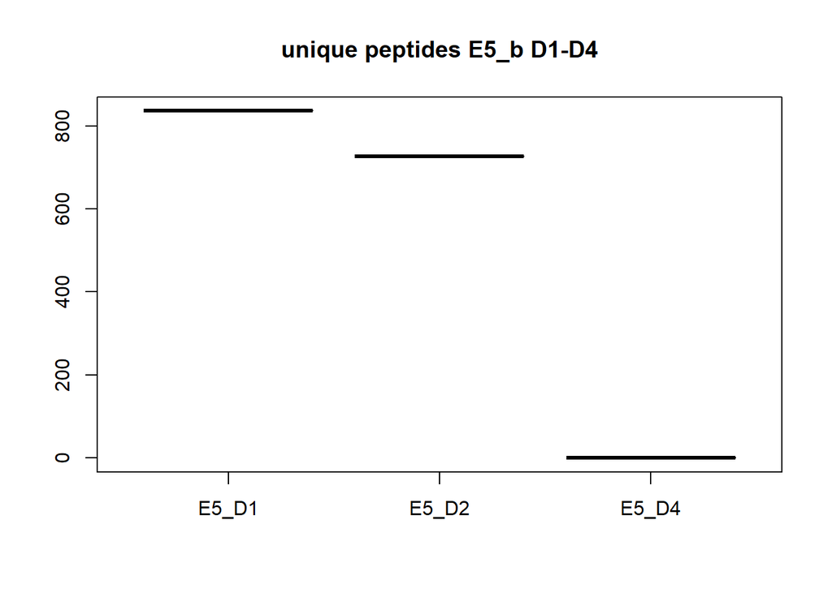

```r
data <- readRDS("./27_20230201_FH/results/D5_extracts_Razor.RDS")
data <- data[[1]]
b <- dplyr::select(data, contains("_b"))
D1_b <- b$Razor...unique.peptides.1_b_01+ b$Razor...unique.peptides.1_b_02
D2_b <- b$Razor...unique.peptides.2_b_01 + b$Razor...unique.peptides.2_b_02
D4_b <- b$Razor...unique.peptides.3_b_01 + b$Razor...unique.peptides.4_b_02
b <- as.data.frame(cbind(D1_b,D2_b,D4_b))
b[b==0] <- NA
b[b==2] <- 1
boxplot(sum(b$Razor...unique.peptides.1_b_01,na.rm = TRUE),
        sum(b$Razor...unique.peptides.2_b_01,na.rm = TRUE),
        sum(b$Razor...unique.peptides.4_b_01,na.rm = TRUE),
        names = c("E5_D1","E5_D2","E5_D4"),
        main="unique peptides E5_b D1-D4")
```

```r
#venn diagram
proteins <- as.data.frame(which(!is.na(b), arr.ind=TRUE))
D1_b <- proteins %>% dplyr::filter(col == 1)
D2_b <- proteins %>% dplyr::filter(col == 2)
D4_b <- proteins %>% dplyr::filter(col == 3)

# combine to list
lst <- list(E5_D1_b = as.double(D1_b[,1]),
            E5_D2_b = as.double(D2_b[,1]),
            E5_D4_b = as.double(D4_b[,1]))
#upset r
upset(fromList(lst),
      order.by = "freq",
      nsets = 9,
      nintersects = 15,
      sets = c("E5_D1_b","E5_D2_b","E5_D4_b"),
      keep.order = TRUE,
      mainbar.y.label = "Number of shared proteins",
      sets.x.label = "Number of proteins per fraction",
      set_size.show = TRUE,
      set_size.angles = 0,
      set_size.scale_max = 1500
)
```

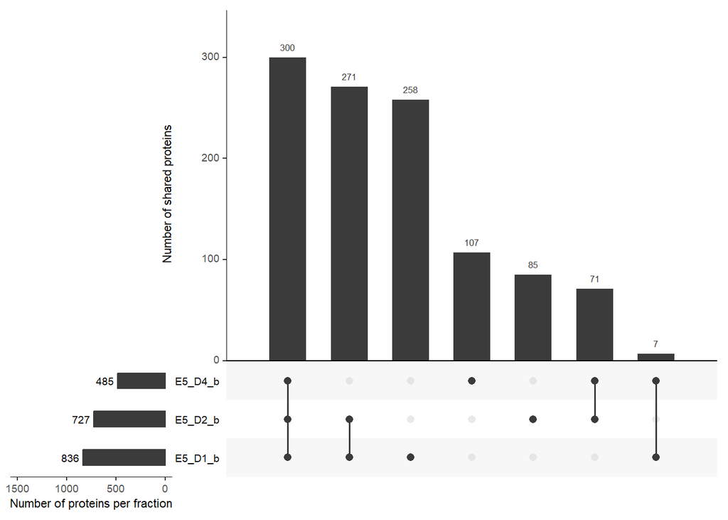

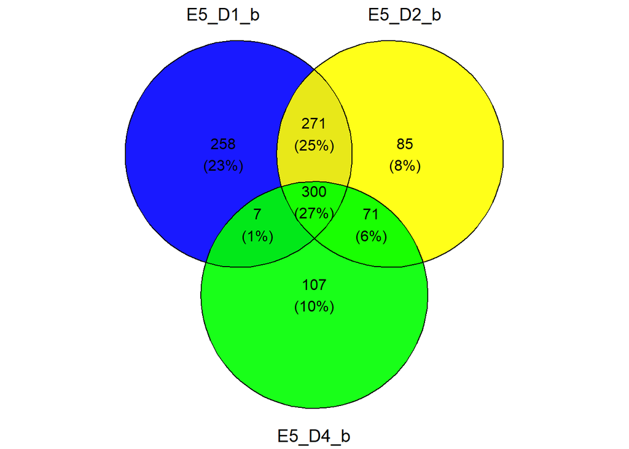

```r
# venn diagram
ggvenn(lst,
       stroke_size = 0.5, set_name_size = 5, text_size = 4.25, digits = 0, fill_alpha = 0.9, label_sep = )
```

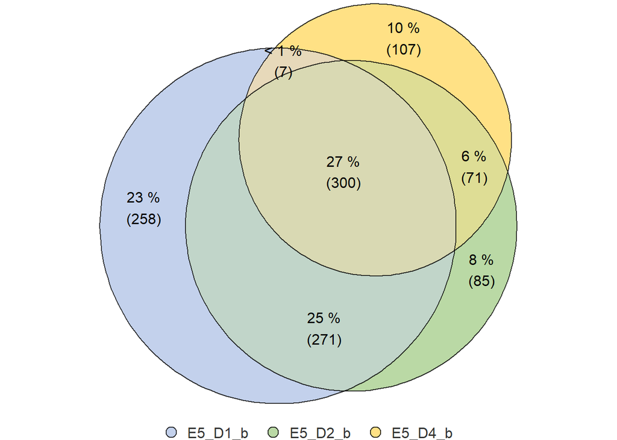

```r
euler_venn_3comp(lst, label_venn = c("E5_D1_b","E5_D2_b","E5_D4_b"), color_venn = c(IG,highMW,lowMW), cex_venn = c(1,1,1), h_just = 0.5, v_just = 0.5)
```

# 9 Compare E4 mit E5

## 9.1 E4 - D1/D2 mit E5 D1-D4

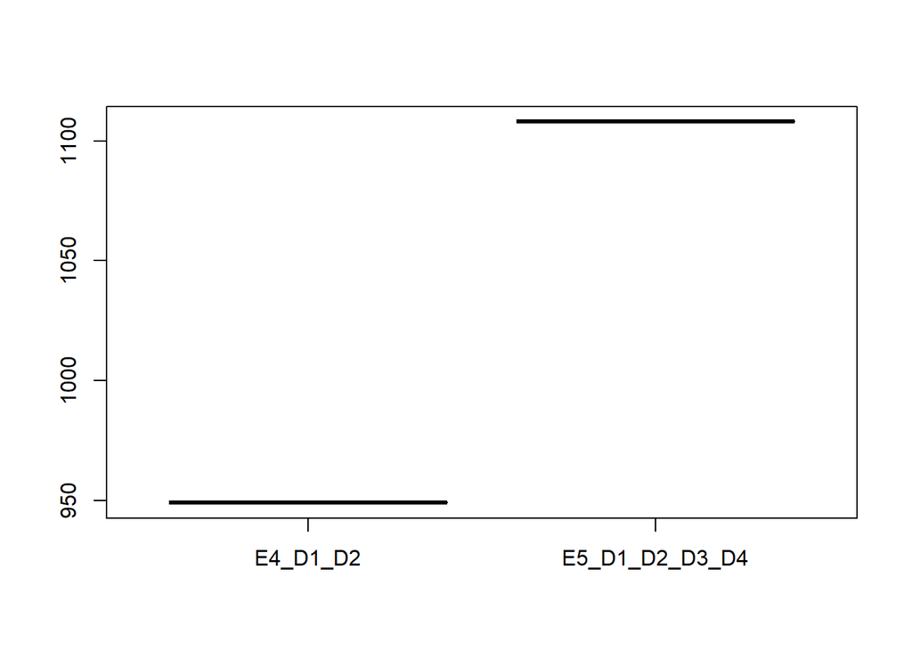

```r
# D1-D2 comparison
D1_raw <- readRDS(file = "results_v002/results_run1_mqpar_extracts_2gether_E4_D1_a-j_LFQ_combined_txt_proteinGroups.txt_Unique.RDS")
D1_raw <- D1_raw[[1]]
D1 <- dplyr::select(D1_raw, contains("Pool"))
D1 <- apply(D1, 1, any)
#D1 <- as.data.frame(cbind(D1, D1_raw$FASTA))
fasta <- c()
for (i in 1:length(D1_raw$FASTA)){
  tmp <- strsplit(D1_raw$FASTA[i],split='\\|')[[1]][2]
  fasta <- c(fasta,tmp)
}
D1 <- as.data.frame(cbind(D1, fasta))
D2_raw <- readRDS(file = "results_v002/results_run1_mqpar_extracts_2gether_D2_LFQ_combined_txt_proteinGroups.txt_Unique.RDS")
D2_raw <- D2_raw[[1]]
D2 <- dplyr::select(D2_raw, contains("Gesamt"))
D2 <- apply(D2, 1, any)
fasta <- c()
for (i in 1:length(D2_raw$FASTA)){
  tmp <- strsplit(D2_raw$FASTA[i],split='\\|')[[1]][2]
  fasta <- c(fasta,tmp)
}
#D2 <- as.data.frame(cbind(D2, D2_raw$FASTA))
D2 <- as.data.frame(cbind(D2, fasta))
D1_D2_comparison  <- merge(D1, D2,
                           all = TRUE,
                           by = "fasta")
D1_D2_comparison$comb <- apply(D1_D2_comparison[,c(2:3)], 1, any)
#E5
data <- readRDS("./27_20230201_FH/results/D5_extracts_Razor.RDS")
data <- data[[1]]
b <- dplyr::select(data, contains("_b"))
b <- as.data.frame(apply(b, 1, any))
fasta <- c()
for (i in 1:length(data$FASTA)){
  tmp <- strsplit(data$FASTA[i],split='\\|')[[1]][2]
  fasta <- c(fasta,tmp)
}
b$fasta <- fasta
colnames(b) <- c("b","fasta")

#merge with D5
D1_D2_D5_comparison  <- merge(D1_D2_comparison[,c(1,4)],b,
                           all = TRUE,
                           by = "fasta")
colnames(D1_D2_D5_comparison) <- c("fasta","E4","E5")

D1_D2_D5_comparison$D1 <- as.logical(D1_D2_D5_comparison$E4)
D1_D2_D5_comparison$D2 <- as.logical(D1_D2_D5_comparison$E5)
D1_D2_D5_comparison <- D1_D2_D5_comparison[,-1]*1
D1_D2_D5_comparison[D1_D2_D5_comparison==0] <- NA

# boxplot
boxplot(sum(D1_D2_D5_comparison$E4,na.rm = TRUE),
        sum(D1_D2_D5_comparison$E5,na.rm = TRUE),
        names = c("E4_D1_D2","E5_D1_D2_D3_D4"))
```

```r
proteins <- as.data.frame(which(!is.na(D1_D2_D5_comparison), arr.ind=TRUE))

E4_inter <- proteins %>% dplyr::filter(col == 1)
E5_inter <- proteins %>% dplyr::filter(col == 2)


# combine to list
lst <- list("E4_D1_D2"=as.double(E4_inter[,1]),
            "E5_D1_D2_D3_D4"=as.double(E5_inter[,1]))

upset(fromList(lst),
      order.by = "freq",
      nsets = 10,
      nintersects = 15,
      keep.order = TRUE,
      sets=c("E4_D1_D2", "E5_D1_D2_D3_D4"),
      mainbar.y.label = "Number of shared proteins",
      sets.x.label = "Number of proteins per fraction",
      set_size.show = TRUE,
      set_size.angles = 0,
      set_size.scale_max = 1500
)
```

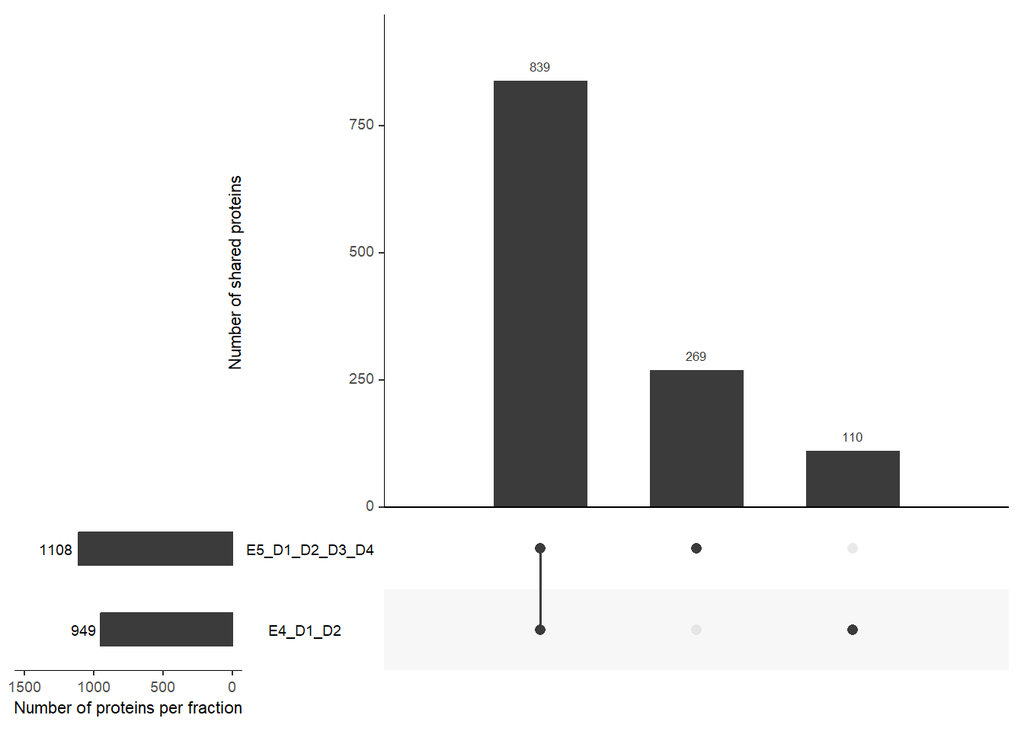

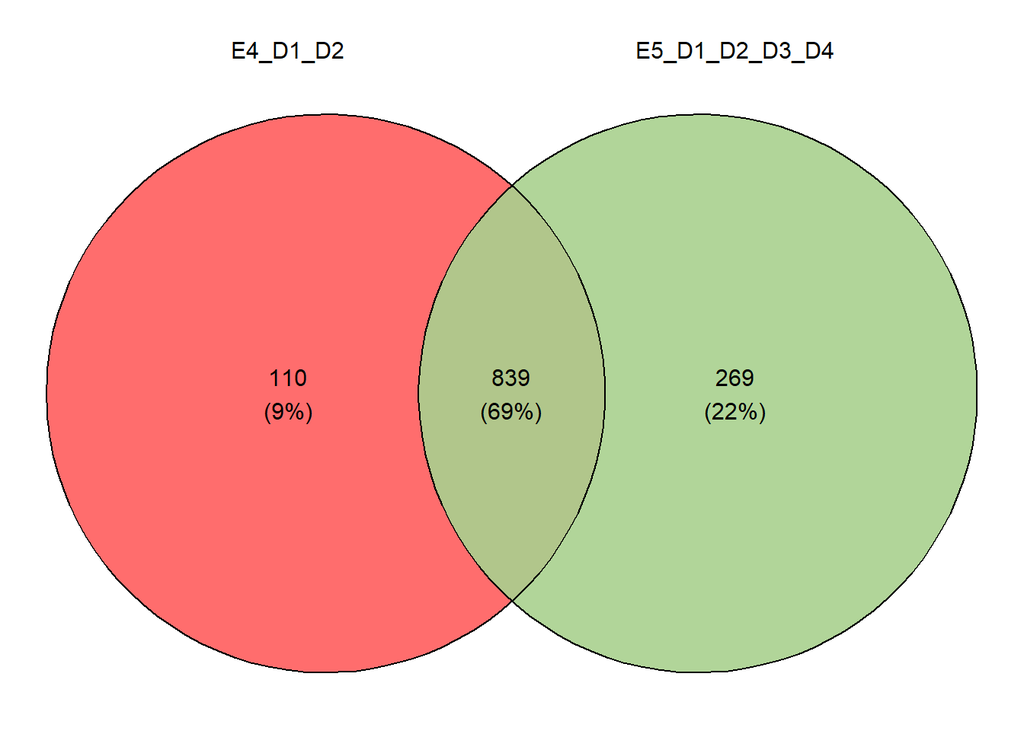

```r
#venn digarams
#get colors
E4_col <- rgb(255,93,93, maxColorValue = 255)
E5_col <- rgb(169,208,142,maxColorValue = 255)

ggvenn(lst,
       fill_color = c(E4_col,E5_col),
       stroke_size = 0.5, set_name_size = 4, text_size = 4, digits = 0, fill_alpha = 0.9)
```

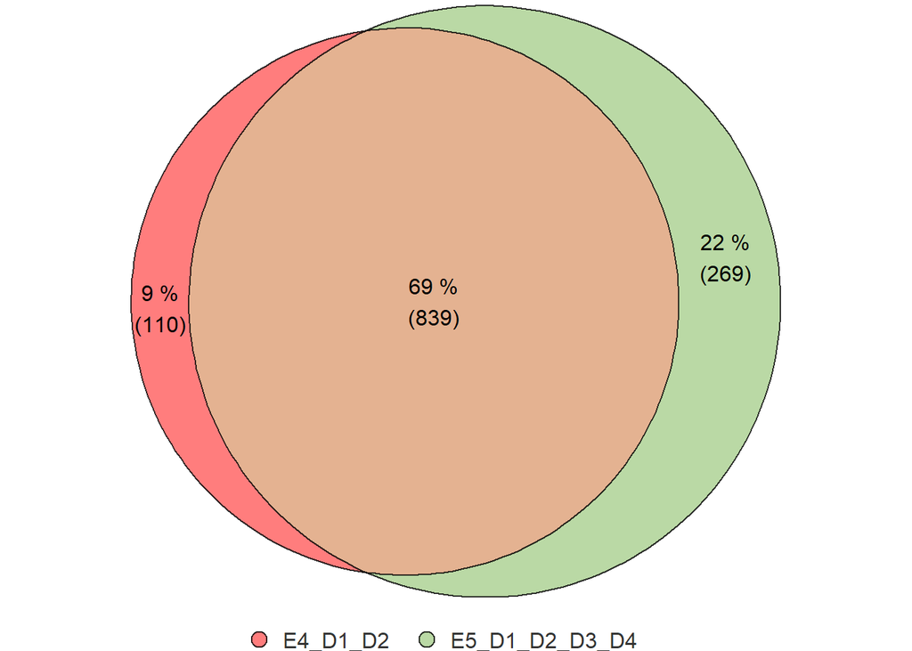

```r
euler_venn_2comp(lst, label_venn = c("E4_D1_D2","E5_D1_D2_D3_D4"), color_venn = c(E4_col,E5_col), cex_venn = c(1,1,1), h_just = 0.5, v_just = 0.5)
```

```r
print( c("E4_D1_D2","E5_D1_D2_D3_D4"))
```

```
## [1] "E4_D1_D2"       "E5_D1_D2_D3_D4"
```

```r
sum(D1_D2_D5_comparison$E4,na.rm = TRUE)
```

```
## [1] 949
```

```r
sum(D1_D2_D5_comparison$E5,na.rm = TRUE)
```

```
## [1] 1108
```

## 9.2 E4 - D1/D2 mit E5 D1,D2 und D4

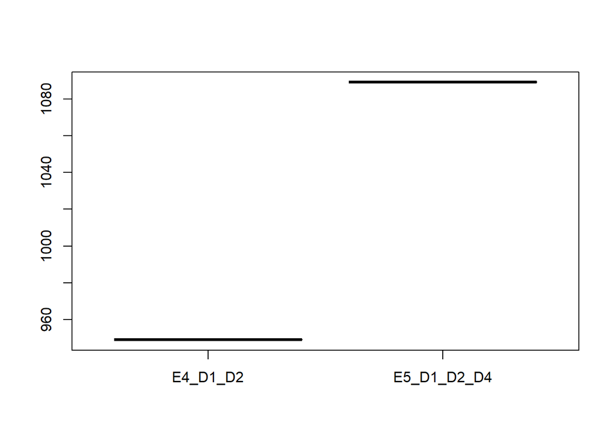

```r
# D1-D2 comparison
D1_raw <- readRDS(file = "results_v002/results_run1_mqpar_extracts_2gether_E4_D1_a-j_LFQ_combined_txt_proteinGroups.txt_Unique.RDS")
D1_raw <- D1_raw[[1]]
D1 <- dplyr::select(D1_raw, contains("Pool"))
D1 <- apply(D1, 1, any)
#D1 <- as.data.frame(cbind(D1, D1_raw$FASTA))
fasta <- c()
for (i in 1:length(D1_raw$FASTA)){
  tmp <- strsplit(D1_raw$FASTA[i],split='\\|')[[1]][2]
  fasta <- c(fasta,tmp)
}
D1 <- as.data.frame(cbind(D1, fasta))
D2_raw <- readRDS(file = "results_v002/results_run1_mqpar_extracts_2gether_D2_LFQ_combined_txt_proteinGroups.txt_Unique.RDS")
D2_raw <- D2_raw[[1]]
D2 <- dplyr::select(D2_raw, contains("Gesamt"))
D2 <- apply(D2, 1, any)
fasta <- c()
for (i in 1:length(D2_raw$FASTA)){
  tmp <- strsplit(D2_raw$FASTA[i],split='\\|')[[1]][2]
  fasta <- c(fasta,tmp)
}
#D2 <- as.data.frame(cbind(D2, D2_raw$FASTA))
D2 <- as.data.frame(cbind(D2, fasta))
D1_D2_comparison  <- merge(D1, D2,
                           all = TRUE,
                           by = "fasta")
D1_D2_comparison$comb <- apply(D1_D2_comparison[,c(2:3)], 1, any)
#E5
data <- readRDS("./27_20230201_FH/results/D5_extracts_Razor.RDS")
data <- data[[1]]
b <- dplyr::select(data, contains("_b"))
b <- b[,-c(5:6)]
b <- as.data.frame(apply(b, 1, any))
fasta <- c()
for (i in 1:length(data$FASTA)){
  tmp <- strsplit(data$FASTA[i],split='\\|')[[1]][2]
  fasta <- c(fasta,tmp)
}
b$fasta <- fasta
colnames(b) <- c("b","fasta")

#merge with D5
D1_D2_D5_comparison  <- merge(D1_D2_comparison[,c(1,4)],b,
                           all = TRUE,
                           by = "fasta")
colnames(D1_D2_D5_comparison) <- c("fasta","E4","E5")

D1_D2_D5_comparison$D1 <- as.logical(D1_D2_D5_comparison$E4)
D1_D2_D5_comparison$D2 <- as.logical(D1_D2_D5_comparison$E5)
D1_D2_D5_comparison <- D1_D2_D5_comparison[,-1]*1
D1_D2_D5_comparison[D1_D2_D5_comparison==0] <- NA

# boxplot
boxplot(sum(D1_D2_D5_comparison$E4,na.rm = TRUE),
        sum(D1_D2_D5_comparison$E5,na.rm = TRUE),
        names = c("E4_D1_D2","E5_D1_D2_D4"))
```

```r
proteins <- as.data.frame(which(!is.na(D1_D2_D5_comparison), arr.ind=TRUE))

E4_inter <- proteins %>% dplyr::filter(col == 1)
E5_inter <- proteins %>% dplyr::filter(col == 2)


# combine to list
lst <- list("E4_D1_D2"=as.double(E4_inter[,1]),
            "E5_D1_D2_D4"=as.double(E5_inter[,1]))

upset(fromList(lst),
      order.by = "freq",
      nsets = 10,
      nintersects = 15,
      keep.order = TRUE,
      sets=c("E4_D1_D2", "E5_D1_D2_D4"),
      mainbar.y.label = "Number of shared proteins",
      sets.x.label = "Number of proteins per fraction",
      set_size.show = TRUE,
      set_size.angles = 0,
      set_size.scale_max = 1500
)
```

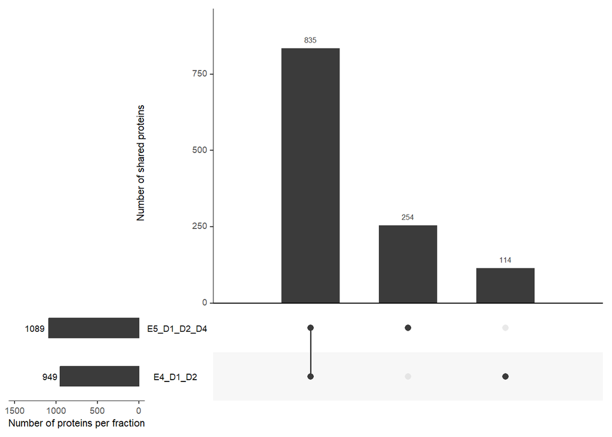

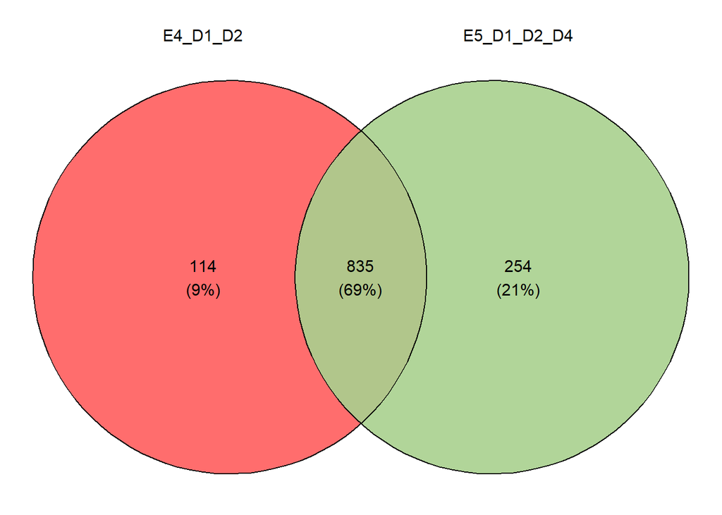

```r
#venn digarams
#get colors
E4_col <- rgb(255,93,93, maxColorValue = 255)
E5_col <- rgb(169,208,142,maxColorValue = 255)

ggvenn(lst,
       fill_color = c(E4_col,E5_col),
       stroke_size = 0.5, set_name_size = 4, text_size = 4, digits = 0, fill_alpha = 0.9)
```

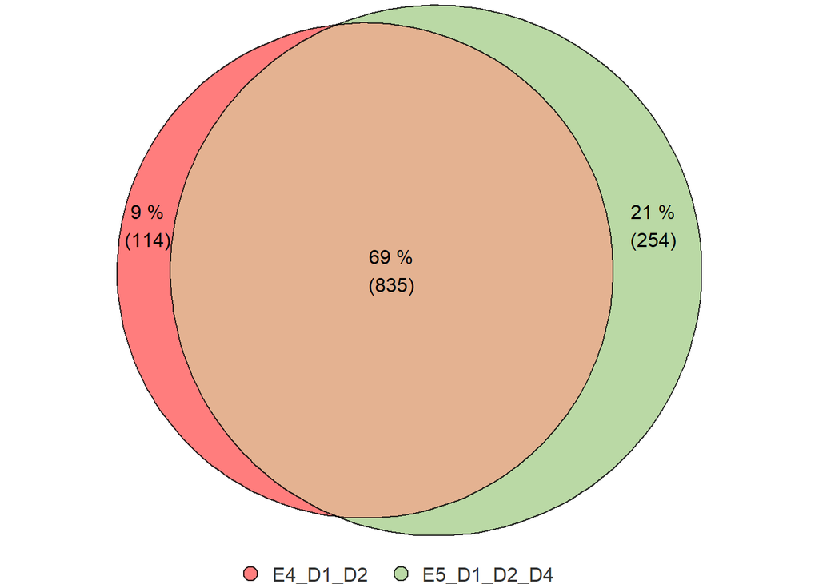

```r
euler_venn_2comp(lst, label_venn = c("E4_D1_D2","E5_D1_D2_D4"), color_venn = c(E4_col,E5_col), cex_venn = c(1,1,1), h_just = 0.5, v_just = 0.5)
```

```r
print(c("E4_D1_D2","E5_D1_D2_D4"))
```

```
## [1] "E4_D1_D2"    "E5_D1_D2_D4"
```

```r
sum(D1_D2_D5_comparison$E4,na.rm = TRUE)
```

```
## [1] 949
```

```r
sum(D1_D2_D5_comparison$E5,na.rm = TRUE)
```

```
## [1] 1089
```

## 9.3 E4D1 mit E5D1

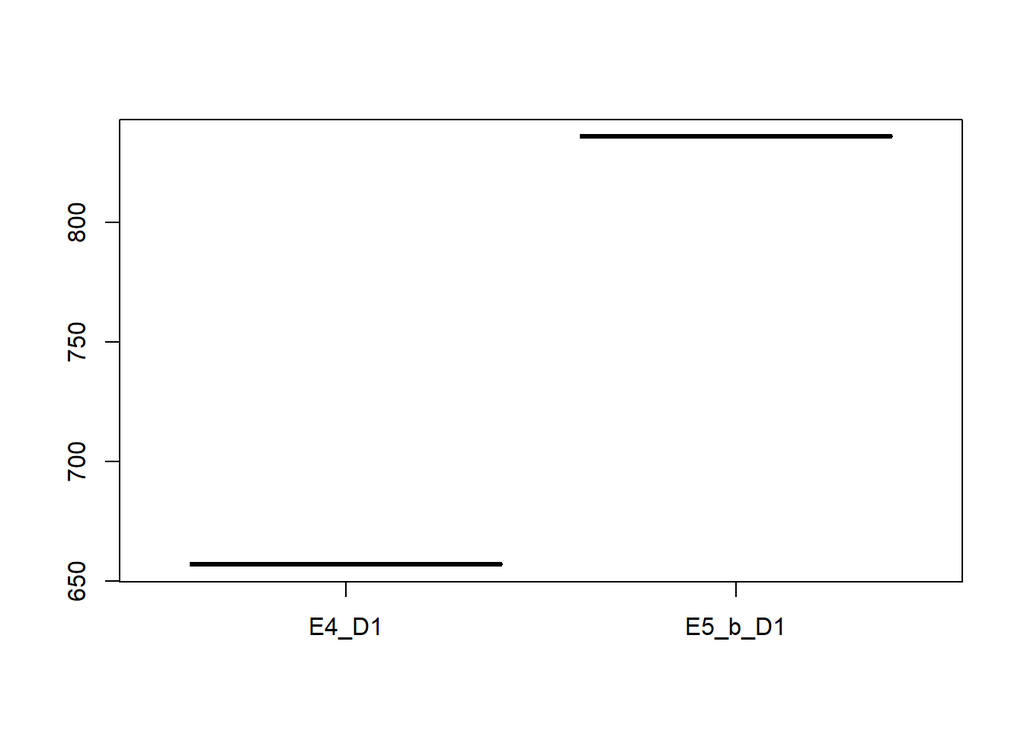

```r
# E4_D1
D1_raw <- readRDS(file = "results_v002/results_run1_mqpar_extracts_2gether_E4_D1_a-j_LFQ_combined_txt_proteinGroups.txt_Unique.RDS")
D1_raw <- D1_raw[[1]]
D1 <- dplyr::select(D1_raw, contains("Pool"))
D1 <- apply(D1, 1, any)
#D1 <- as.data.frame(cbind(D1, D1_raw$FASTA))
fasta <- c()
for (i in 1:length(D1_raw$FASTA)){
  tmp <- strsplit(D1_raw$FASTA[i],split='\\|')[[1]][2]
  fasta <- c(fasta,tmp)
}
D1 <- as.data.frame(cbind(D1, fasta))

#E5
data <- readRDS("./27_20230201_FH/results/D5_extracts_Razor.RDS")
data <- data[[1]]
b <- dplyr::select(data, contains("1_b"))
b <- as.data.frame(apply(b, 1, any))
fasta <- c()
for (i in 1:length(data$FASTA)){
  tmp <- strsplit(data$FASTA[i],split='\\|')[[1]][2]
  fasta <- c(fasta,tmp)
}
b$fasta <- fasta
colnames(b) <- c("b","fasta")

#merge with D5
E4_E5_comparison  <- merge(D1,b,
                           all = TRUE,
                           by = "fasta")
colnames(E4_E5_comparison) <- c("fasta","E4","E5")

E4_E5_comparison$E4 <- as.logical(E4_E5_comparison$E4)
E4_E5_comparison$E5 <- as.logical(E4_E5_comparison$E5)
E4_E5_comparison <- E4_E5_comparison[,-1]*1
E4_E5_comparison[E4_E5_comparison==0] <- NA



# boxplot
boxplot(sum(E4_E5_comparison$E4,na.rm = TRUE),
        sum(E4_E5_comparison$E5,na.rm = TRUE),
        names = c("E4_D1","E5_b_D1"))
```

```r
proteins <- as.data.frame(which(!is.na(E4_E5_comparison), arr.ind=TRUE))

E4_inter <- proteins %>% dplyr::filter(col == 1)
E5_inter <- proteins %>% dplyr::filter(col == 2)


# combine to list
lst <- list("E4_D1"=as.double(E4_inter[,1]),
            "E5_b_D1"=as.double(E5_inter[,1]))

upset(fromList(lst),
      order.by = "freq",
      nsets = 10,
      nintersects = 15,
      keep.order = TRUE,
      sets=c("E4_D1", "E5_b_D1"),
      mainbar.y.label = "Number of shared proteins",
      sets.x.label = "Number of proteins per fraction",
      set_size.show = TRUE,
      set_size.angles = 0,
      set_size.scale_max = 1500
)
```

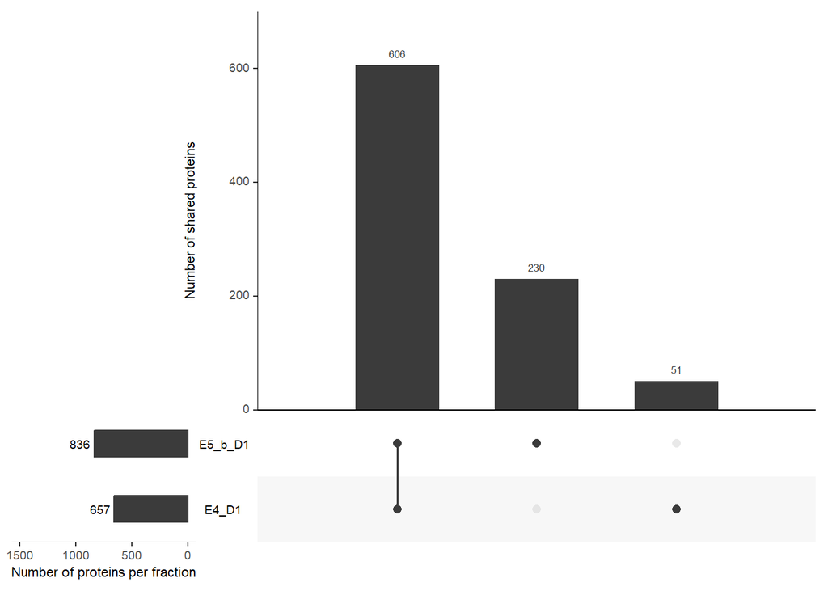

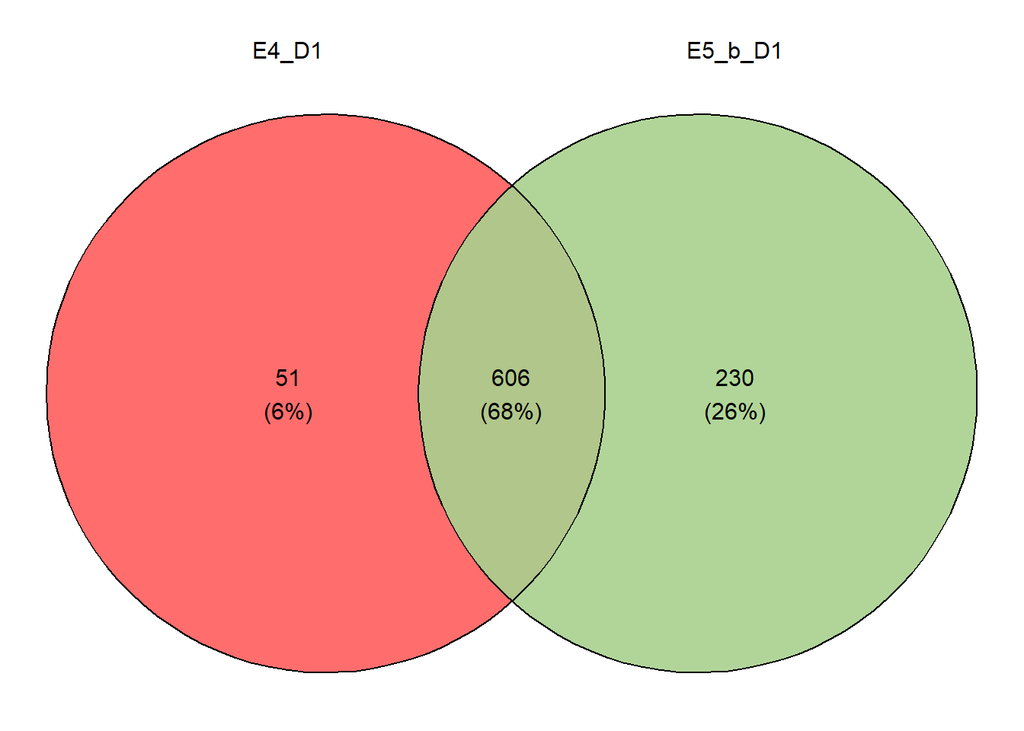

```r
#venn digarams
#get colors
E4_col <- rgb(255,93,93, maxColorValue = 255)
E5_col <- rgb(169,208,142,maxColorValue = 255)

ggvenn(lst,
       fill_color = c(E4_col,E5_col),
       stroke_size = 0.5, set_name_size = 4, text_size = 4, digits = 0, fill_alpha = 0.9)
```

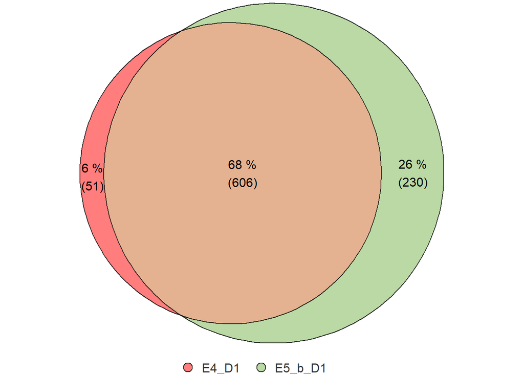

```r
euler_venn_2comp(lst, label_venn = c("E4_D1","E5_b_D1"), color_venn = c(E4_col,E5_col), cex_venn = c(1,1,1), h_just = 0.5, v_just = 0.5)
```

```r
print(c("E4_D1","E5_b_D1"))
```

```
## [1] "E4_D1"   "E5_b_D1"
```

```r
sum(E4_E5_comparison$E4,na.rm = TRUE)
```

```
## [1] 657
```

```r
sum(E4_E5_comparison$E5,na.rm = TRUE)
```

```
## [1] 836
```

## 9.4 E4 D2 mit E5 D2 mit E5 D4

- hier wurden also 3 Gruppen verglichen

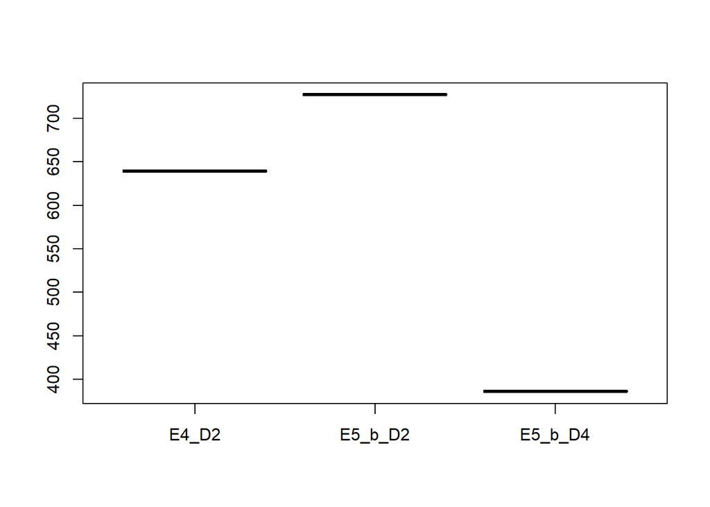

```r
# E4-D2 comparison
D2_raw <- readRDS(file = "results_v002/results_run1_mqpar_extracts_2gether_D2_LFQ_combined_txt_proteinGroups.txt_Unique.RDS")
D2_raw <- D2_raw[[1]]
D2 <- dplyr::select(D2_raw, contains("Gesamt"))
D2 <- apply(D2, 1, any)
fasta <- c()
for (i in 1:length(D2_raw$FASTA)){
  tmp <- strsplit(D2_raw$FASTA[i],split='\\|')[[1]][2]
  fasta <- c(fasta,tmp)
}
#D2 <- as.data.frame(cbind(D2, D2_raw$FASTA))
D2 <- as.data.frame(cbind(D2, fasta))
# E5-D2
data <- readRDS("./27_20230201_FH/results/D5_extracts_Razor.RDS")
data <- data[[1]]
b <- dplyr::select(data, contains("2_b"))
b <- as.data.frame(apply(b, 1, any))
fasta <- c()
for (i in 1:length(data$FASTA)){
  tmp <- strsplit(data$FASTA[i],split='\\|')[[1]][2]
  fasta <- c(fasta,tmp)
}
b$fasta <- fasta
colnames(b) <- c("b","fasta")

###merge E4_D2 pool with E5_D2
comparison  <- merge(D2,b,
                           all = TRUE,
                           by = "fasta")
colnames(comparison) <- c("fasta","E4_D2","E5_D2")

#E5_D4
data <- readRDS("./27_20230201_FH/results/D5_extracts_Razor.RDS")
data <- data[[1]]
b <- dplyr::select(data, contains("4_b"))
b <- as.data.frame(apply(b, 1, any))
fasta <- c()
for (i in 1:length(data$FASTA)){
  tmp <- strsplit(data$FASTA[i],split='\\|')[[1]][2]
  fasta <- c(fasta,tmp)
}
b$fasta <- fasta
colnames(b) <- c("b","fasta")

###merge E4_D2 poo&E5_D2 with E5_D4
comparison  <- merge(comparison,b,
                     all = TRUE,
                     by = "fasta")
colnames(comparison) <- c("fasta","E4_D2","E5_D2","E5_D4")

comparison$E4_D2 <- as.logical(comparison$E4_D2)
comparison$E5_D2 <- as.logical(comparison$E5_D2)
comparison$E5_D4 <- as.logical(comparison$E5_D4)
comparison <- comparison[,-1]*1
comparison[comparison==0] <- NA

# boxplot
boxplot(sum(comparison$E4_D2,na.rm = TRUE),
        sum(comparison$E5_D2,na.rm = TRUE),
        sum(comparison$E5_D4,na.rm = TRUE),
        names = c("E4_D2","E5_b_D2","E5_b_D4"))
```

```r
proteins <- as.data.frame(which(!is.na(comparison), arr.ind=TRUE))

E4_inter <- proteins %>% dplyr::filter(col == 1)
E5_inter <- proteins %>% dplyr::filter(col == 2)
E5_4_inter <- proteins %>% dplyr::filter(col == 3)



# combine to list
lst <- list("E4_D2"=as.double(E4_inter[,1]),
            "E5_b_D2"=as.double(E5_inter[,1]),
            "E5_b_D4"=as.double(E5_4_inter[,1]))

upset(fromList(lst),
      order.by = "freq",
      nsets = 10,
      nintersects = 15,
      keep.order = TRUE,
      sets=c("E4_D2", "E5_b_D2", "E5_b_D4"),
      mainbar.y.label = "Number of shared proteins",
      sets.x.label = "Number of proteins per fraction",
      set_size.show = TRUE,
      set_size.angles = 0,
      set_size.scale_max = 1500
)
```

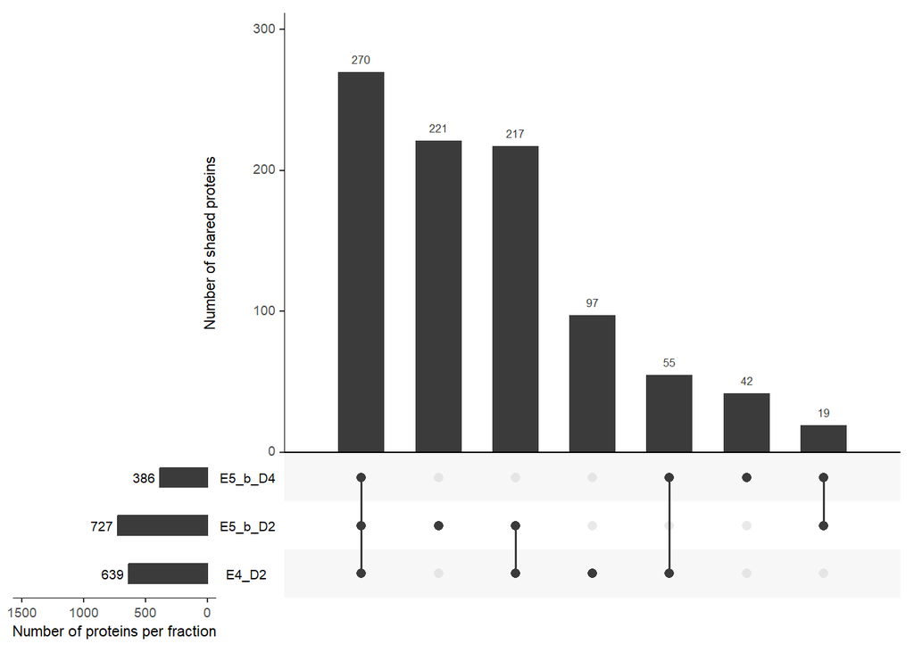

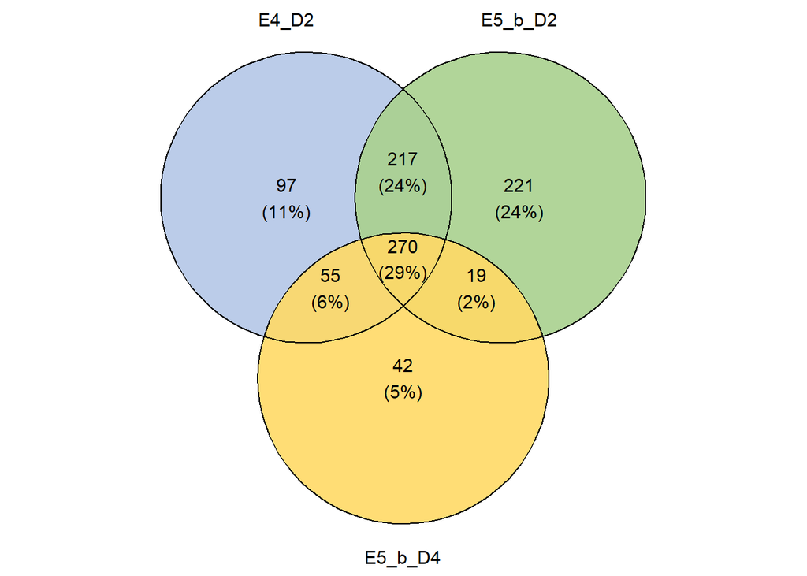

```r
ggvenn(lst,
       fill_color = c(IG, highMW, lowMW),
       stroke_size = 0.5, set_name_size = 4, text_size = 4, digits = 0, fill_alpha = 0.9)
```

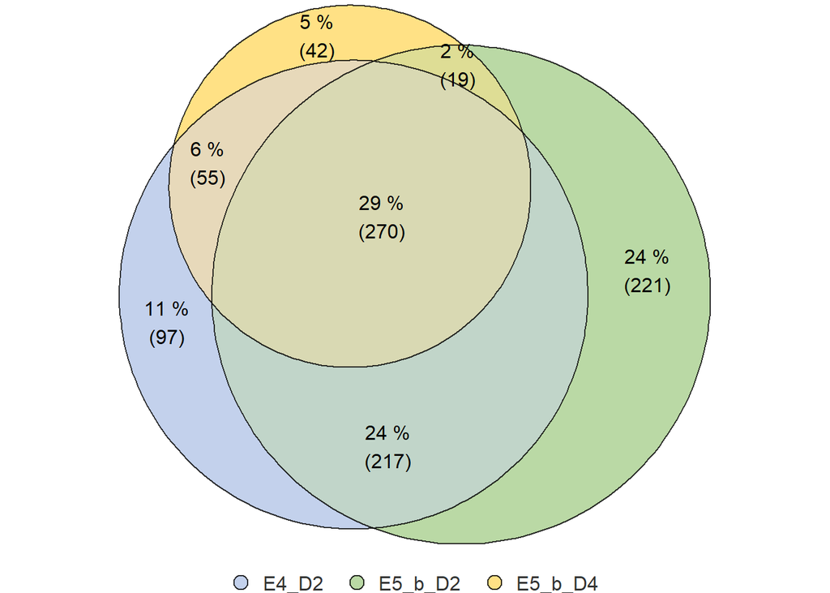

```r
euler_venn_3comp(lst, label_venn = c("E4_D2","E5_b_D2","E5_b_D4"), color_venn = c(IG, highMW, lowMW), cex_venn = c(1,1,1), h_just = 0.5, v_just = 0.5)
```

```r
print(c("E4_D2","E5_b_D2","E5_b_D4"))
```

```
## [1] "E4_D2"   "E5_b_D2" "E5_b_D4"
```

```r
sum(comparison$E4_D2,na.rm = TRUE)
```

```
## [1] 639
```

```r
sum(comparison$E5_D2,na.rm = TRUE)
```

```
## [1] 727
```

```r
sum(comparison$E5_D4,na.rm = TRUE)
```

```
## [1] 386
```

## 9.5 E4 D2 mit merge(E5 D2/E5 D4)

- im vergleich zum oberen punkt wurde zuerst D2 und D4 von E5 zusammengefasst und dieses Ergebnis dann mit E4 D2 verglichen

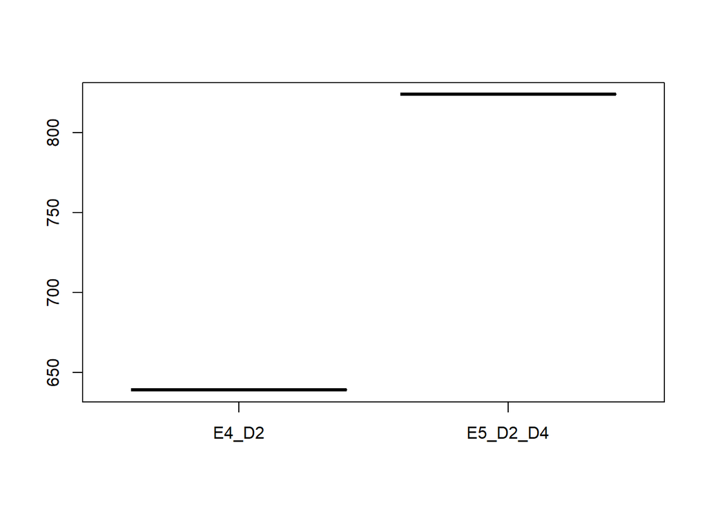

```r
# E4-D2 comparison
D2_raw <- readRDS(file = "results_v002/results_run1_mqpar_extracts_2gether_D2_LFQ_combined_txt_proteinGroups.txt_Unique.RDS")
D2_raw <- D2_raw[[1]]
D2 <- dplyr::select(D2_raw, contains("Gesamt"))
D2 <- apply(D2, 1, any)
fasta <- c()
for (i in 1:length(D2_raw$FASTA)){
  tmp <- strsplit(D2_raw$FASTA[i],split='\\|')[[1]][2]
  fasta <- c(fasta,tmp)
}
#D2 <- as.data.frame(cbind(D2, D2_raw$FASTA))
D2 <- as.data.frame(cbind(D2, fasta))
# E5-D2
data <- readRDS("./27_20230201_FH/results/D5_extracts_Razor.RDS")
data <- data[[1]]
b <- dplyr::select(data, contains("2_b"))
b <- as.data.frame(apply(b, 1, any))
fasta <- c()
for (i in 1:length(data$FASTA)){
  tmp <- strsplit(data$FASTA[i],split='\\|')[[1]][2]
  fasta <- c(fasta,tmp)
}
b$fasta <- fasta
colnames(b) <- c("b","fasta")
###merge E4_D2 pool with E5_D2
comparison  <- merge(D2,b,
                           all = TRUE,
                           by = "fasta")
colnames(comparison) <- c("fasta","E4_D2","E5_D2")

#E5_D4
data <- readRDS("./27_20230201_FH/results/D5_extracts_Razor.RDS")
data <- data[[1]]
b <- dplyr::select(data, contains("4_b"))
b <- as.data.frame(apply(b, 1, any))
fasta <- c()
for (i in 1:length(data$FASTA)){
  tmp <- strsplit(data$FASTA[i],split='\\|')[[1]][2]
  fasta <- c(fasta,tmp)
}
b$fasta <- fasta
colnames(b) <- c("b","fasta")

###merge E4_D2 poo&E5_D2 with E5_D4
comparison  <- merge(comparison,b,
                     all = TRUE,
                     by = "fasta")
colnames(comparison) <- c("fasta","E4_D2","E5_D2","E5_D4")

comparison$comb_E5 <- apply(comparison[,c(3:4)], 1, any)


comparison$E4_D2 <- as.logical(comparison$E4_D2)
comparison$comb_E5 <- as.logical(comparison$comb_E5)
comparison <- comparison[,-c(1,3,4)]*1
comparison[comparison==0] <- NA

# boxplot
boxplot(sum(comparison$E4_D2,na.rm = TRUE),
        sum(comparison$comb_E5,na.rm = TRUE),
        names = c("E4_D2","E5_D2_D4"))
```

```r
proteins <- as.data.frame(which(!is.na(comparison), arr.ind=TRUE))

E4_inter <- proteins %>% dplyr::filter(col == 1)
E5_inter <- proteins %>% dplyr::filter(col == 2)

# combine to list
lst <- list("E4_D2"=as.double(E4_inter[,1]),
            "E5_D2_D4"=as.double(E5_inter[,1]))

upset(fromList(lst),
      order.by = "freq",
      nsets = 10,
      nintersects = 15,
      keep.order = TRUE,
      sets=c("E4_D2", "E5_D2_D4"),
      mainbar.y.label = "Number of shared proteins",
      sets.x.label = "Number of proteins per fraction",
      set_size.show = TRUE,
      set_size.angles = 0,
      set_size.scale_max = 1500
)
```

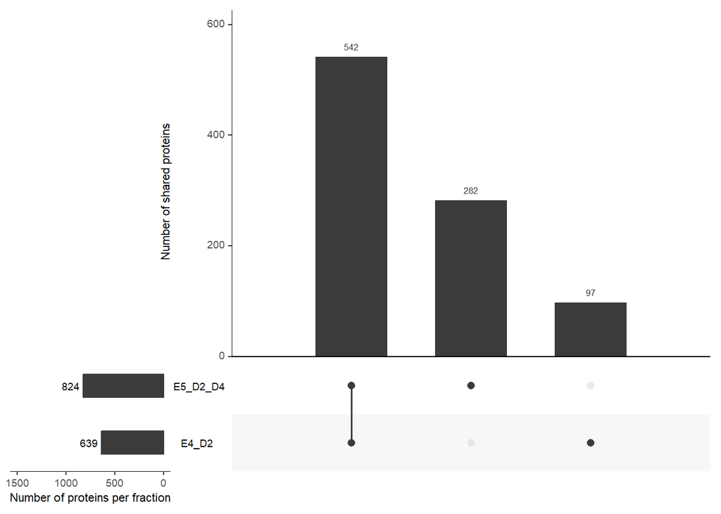

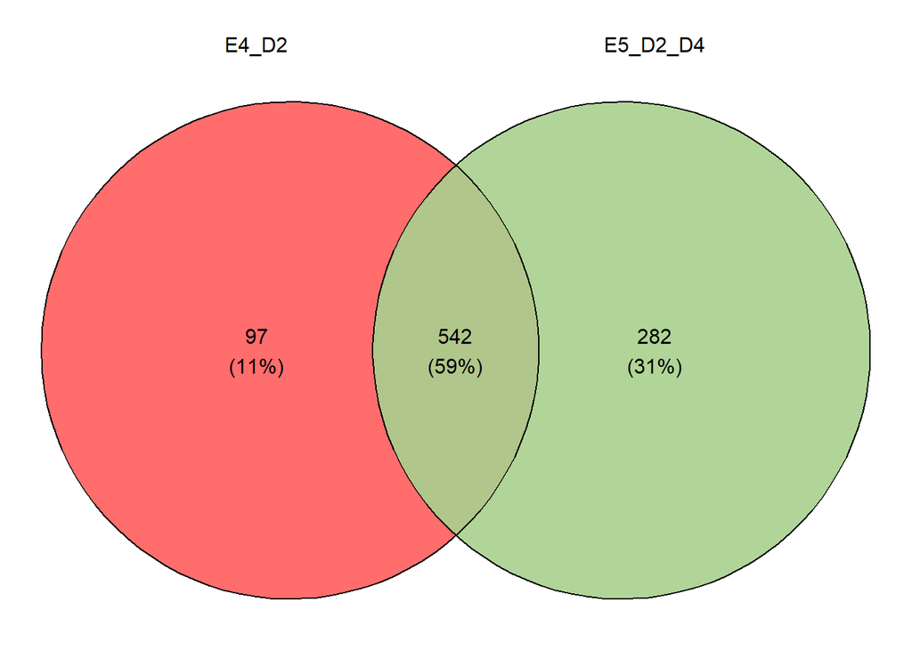

```r
ggvenn(lst,
       fill_color = c(E4_col,E5_col),
       stroke_size = 0.5, set_name_size = 4, text_size = 4, digits = 0, fill_alpha = 0.9)
```

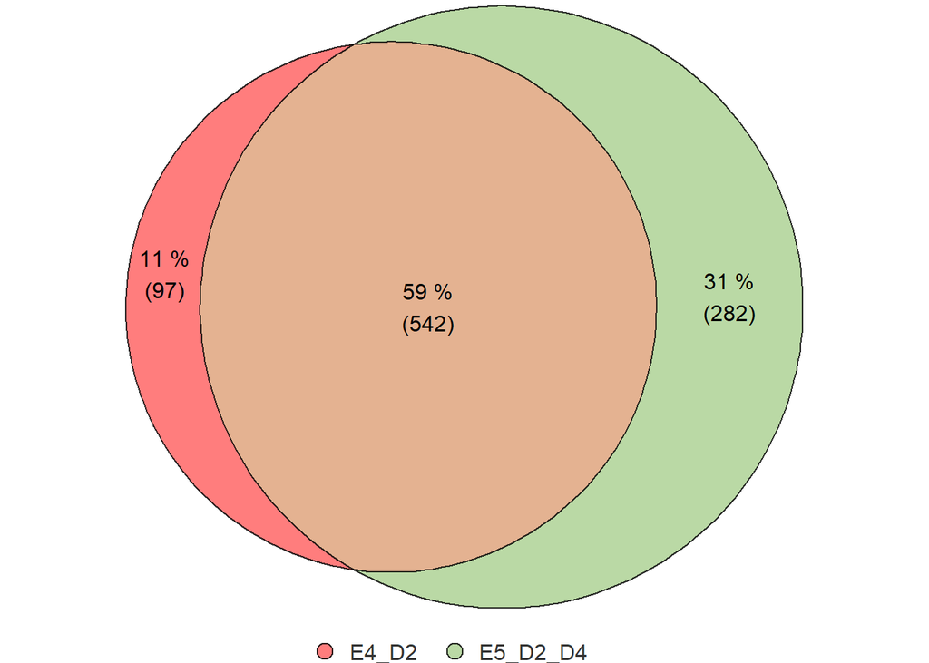

```r
euler_venn_2comp(lst, label_venn = c("E4_D2","E5_D2_D4"), color_venn = c(E4_col,E5_col), cex_venn = c(1,1,1), h_just = 0.5, v_just = 0.5)
```

```r
print(c("E4_D2","E5_D2_D4"))
```

```
## [1] "E4_D2"    "E5_D2_D4"
```

```r
sum(comparison$E4_D2,na.rm = TRUE)
```

```
## [1] 639
```

```r
sum(comparison$comb_E5,na.rm = TRUE)
```

```
## [1] 824
```

# 10 E3_D1 bzw E4_D1 und E5_D1

- bei E3 e und f genommen (je 3 fach Messung) da das mit Proteaseinhibitor ist
- bei E4 pool das waren 2 Messungen
- bei E5 habe ich 1_b genommen - 2 messungen

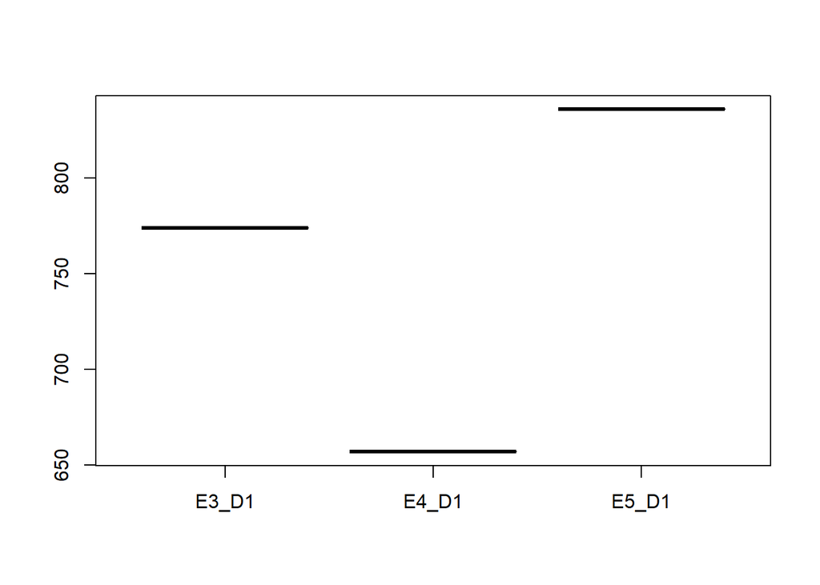

```r
#E3_D1
D1_raw <- readRDS(file = "results_v002/results_run1_mqpar_extracts_2gether_E3_D1_LFQ_combined_txt_proteinGroups.txt_Unique.RDS")
D1_raw <- D1_raw[[1]]
D1 <- D1_raw[,c(13:18)]
D1 <- apply(D1, 1, any)
#D1 <- as.data.frame(cbind(D1, D1_raw$FASTA))
fasta <- c()
for (i in 1:length(D1_raw$FASTA)){
  tmp <- strsplit(D1_raw$FASTA[i],split='\\|')[[1]][2]
  fasta <- c(fasta,tmp)
}
E3_D1 <- as.data.frame(cbind(D1, fasta))
#E4_D1
D1_raw <- readRDS(file = "results_v002/results_run1_mqpar_extracts_2gether_E4_D1_a-j_LFQ_combined_txt_proteinGroups.txt_Unique.RDS")
D1_raw <- D1_raw[[1]]
D1 <- dplyr::select(D1_raw, contains("Pool"))
D1 <- apply(D1, 1, any)
#D1 <- as.data.frame(cbind(D1, D1_raw$FASTA))
fasta <- c()
for (i in 1:length(D1_raw$FASTA)){
  tmp <- strsplit(D1_raw$FASTA[i],split='\\|')[[1]][2]
  fasta <- c(fasta,tmp)
}
E4_D1 <- as.data.frame(cbind(D1, fasta))
#E5_D1
data_raw <- readRDS("./27_20230201_FH/results/D5_extracts_Razor.RDS")
data_raw <- data_raw[[1]]
E5_D1 <- dplyr::select(data_raw, contains("1_b"))
E5_D1 <- apply(E5_D1, 1, any)
fasta <- c()
for (i in 1:length(data_raw$FASTA)){
  tmp <- strsplit(data_raw$FASTA[i],split='\\|')[[1]][2]
  fasta <- c(fasta,tmp)
}
E5_D1 <- as.data.frame(cbind(E5_D1, fasta))

#### merging
comparison  <- merge(E3_D1, E4_D1,
                           all = TRUE,
                           by = "fasta")

comparison  <- merge(comparison, E5_D1,
                     all = TRUE,
                     by = "fasta")
colnames(comparison) <- c("fasta","E3_D1","E4_D1","E5_D1")

comparison$E3_D1 <- as.logical(comparison$E3_D1)
comparison$E4_D1 <- as.logical(comparison$E4_D1)
comparison$E5_D1 <- as.logical(comparison$E5_D1)
comparison <- comparison[,-1]*1
comparison[comparison==0] <- NA

# boxplot
boxplot(sum(comparison$E3_D1,na.rm = TRUE),
        sum(comparison$E4_D1,na.rm = TRUE),
        sum(comparison$E5_D1,na.rm = TRUE),
        names = c("E3_D1","E4_D1","E5_D1"))
```

```r
proteins <- as.data.frame(which(!is.na(comparison), arr.ind=TRUE))

E3 <- proteins %>% dplyr::filter(col == 1)
E4 <- proteins %>% dplyr::filter(col == 2)
E5 <- proteins %>% dplyr::filter(col == 3)


# combine to list
lst <- list("E3"=as.double(E3[,1]),
            "E4"=as.double(E4[,1]),
            "E5"=as.double(E5[,1]))

upset(fromList(lst),
      order.by = "freq",
      nsets = 10,
      nintersects = 15,
      keep.order = TRUE,
      sets=c("E3","E4", "E5"),
      mainbar.y.label = "Number of shared proteins",
      sets.x.label = "Number of proteins per fraction",
      set_size.show = TRUE,
      set_size.angles = 0,
      set_size.scale_max = 1500
)
```

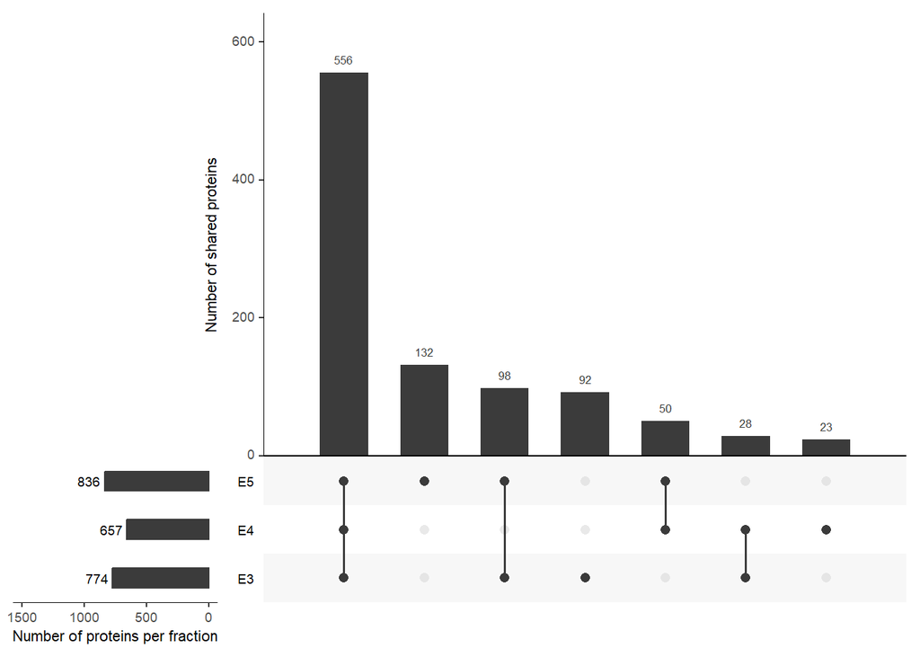

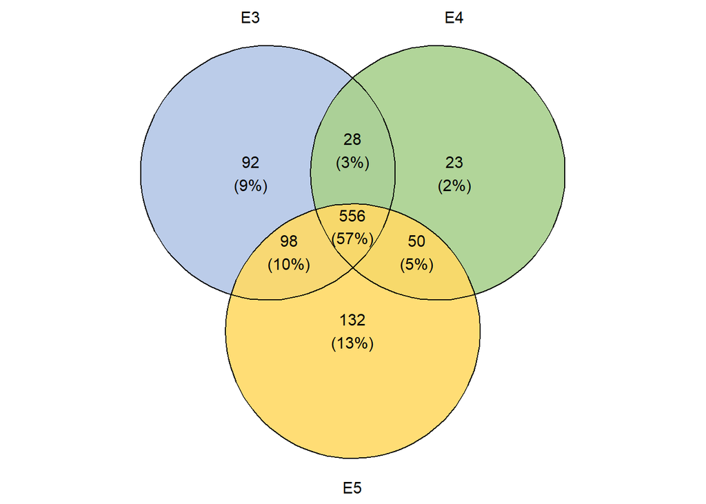

```r
ggvenn(lst,
       fill_color = c(IG,highMW,lowMW),
       stroke_size = 0.5, set_name_size = 4, text_size = 4, digits = 0, fill_alpha = 0.9)
```

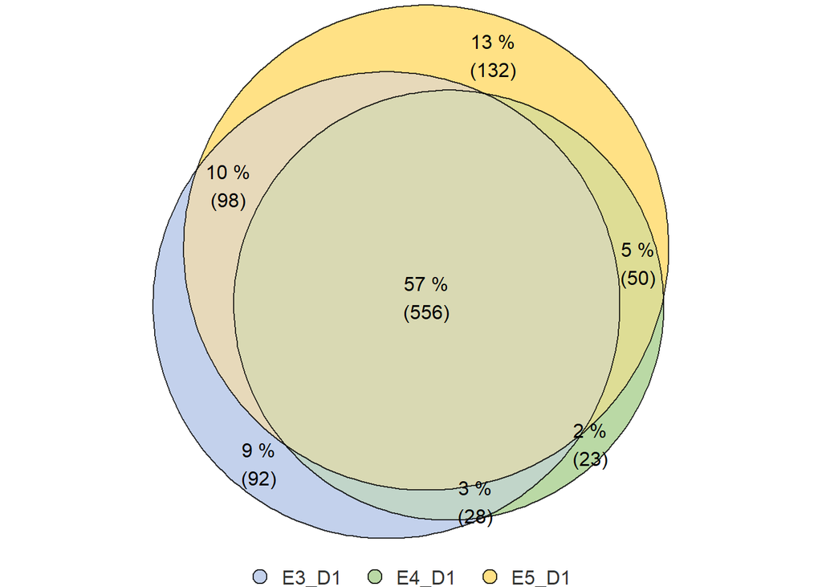

```r
euler_venn_3comp(lst, label_venn = c("E3_D1","E4_D1","E5_D1"), color_venn = c(IG,highMW,lowMW), cex_venn = c(1,1,1), h_just = 0.5, v_just = 0.5)
```

```r
print(c("E3_D1","E4_D1","E5_D1"))
```

```
## [1] "E3_D1" "E4_D1" "E5_D1"
```

```r
sum(comparison$E3_D1,na.rm = TRUE)
```

```
## [1] 774
```

```r
sum(comparison$E4_D1,na.rm = TRUE)
```

```
## [1] 657
```

```r
sum(comparison$E5_D1,na.rm = TRUE)
```

```
## [1] 836
```

# 11 Barplots SDS gels

## 11.1 E4_D1

- manuell von hier abgeschrieben `file://fhwn.ac.at/TU/Forschung/wissenschaftliche%20Ver%C3%B6ffentlichungen/Publikationen/2022/Proteomics_JRS_DL/data/evaluation_summary.html#4_Compare_D1_and_D2_B1-B9_resp_B1-B10`

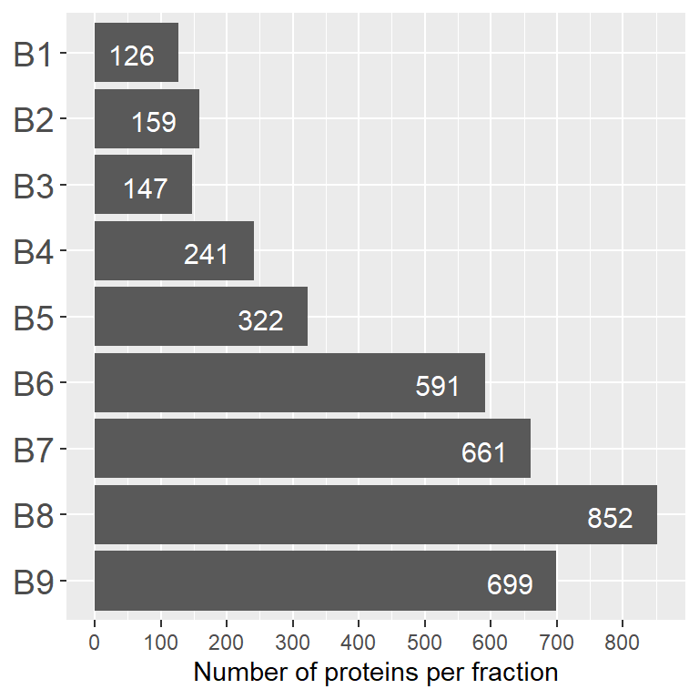

```r
dat <- as.data.frame(
  cbind(c(126,159,147,241,322,591,661,852,699),
        c(paste("B",1:9,sep=""))))
colnames(dat) <- c("no","fraction")
dat$no <- as.numeric(dat$no)

positions <-  c(paste("B",9:1,sep=""))


ggplot(data=dat, aes(x=fraction,y=no))+
  geom_bar(stat="identity") +
  coord_flip() +
  geom_text(aes(label=no), hjust=1.5,vjust=0.6, color="white", size=4) +
  theme(axis.title.y = element_blank(),axis.text.y = element_text(size=14)) +
  scale_y_continuous(breaks = seq(0, 1000, by = 100)) +
  labs(y="Number of proteins per fraction") +
  scale_x_discrete(limits = positions)
```

## 11.2 E4_D2

- manuell von hier abgeschrieben `file:///X:/wissenschaftliche%20Ver%C3%B6ffentlichungen/Publikationen/2022/Proteomics_JRS_DL/data/evaluation_summary_4publication.html#9_D2`

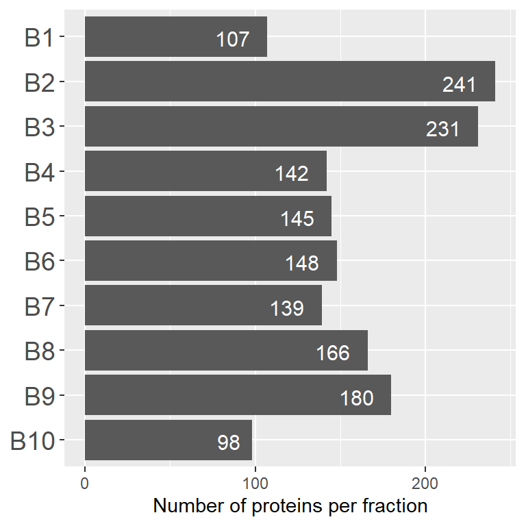

```r
dat <- as.data.frame(
  cbind(c(107,241,231,142,145,148,139,166,180,98),
        c(paste("B",1:10,sep=""))))
colnames(dat) <- c("no","fraction")
dat$no <- as.numeric(dat$no)

positions <-  c(paste("B",10:1,sep=""))

ggplot(data=dat, aes(x=fraction,y=no))+
  geom_bar(stat="identity") +
  coord_flip() +
  geom_text(aes(label=no), hjust=1.5,vjust=0.6, color="white", size=4) +
  theme(axis.title.y = element_blank(),axis.text.y = element_text(size=14)) +
  scale_y_continuous(breaks = seq(0, 1000, by = 100)) +
  scale_x_discrete(limits = positions) +
  labs(y="Number of proteins per fraction")
```

# 12 E3-E5 merge mit E4_D2 und E5_D2_D4

## 12.1 Step1 merge(E3_e_f, E4_D1 (pool), E5_1b) mit E4_D2 E5_D2_D4

- ALLE D1 mergen (von E3_D1_e-f, E4_D1(pool) und E5_1b) und dann im Venn Diagramm mit E4_D2 und dem E5_D2_D4_merge vergleichen

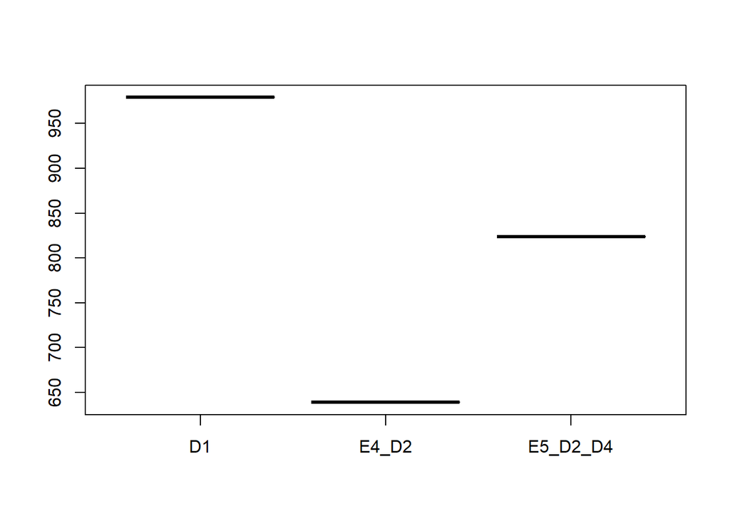

```r
#E3_D1
D1_raw <- readRDS(file = "results_v002/results_run1_mqpar_extracts_2gether_E3_D1_LFQ_combined_txt_proteinGroups.txt_Unique.RDS")
D1_raw <- D1_raw[[1]]
D1 <- D1_raw[,c(13:18)]
D1 <- apply(D1, 1, any)
#D1 <- as.data.frame(cbind(D1, D1_raw$FASTA))
fasta <- c()
for (i in 1:length(D1_raw$FASTA)){
  tmp <- strsplit(D1_raw$FASTA[i],split='\\|')[[1]][2]
  fasta <- c(fasta,tmp)
}
E3_D1 <- as.data.frame(cbind(D1, fasta))
#E4_D1
D1_raw <- readRDS(file = "results_v002/results_run1_mqpar_extracts_2gether_E4_D1_a-j_LFQ_combined_txt_proteinGroups.txt_Unique.RDS")
D1_raw <- D1_raw[[1]]
D1 <- dplyr::select(D1_raw, contains("Pool"))
D1 <- apply(D1, 1, any)
#D1 <- as.data.frame(cbind(D1, D1_raw$FASTA))
fasta <- c()
for (i in 1:length(D1_raw$FASTA)){
  tmp <- strsplit(D1_raw$FASTA[i],split='\\|')[[1]][2]
  fasta <- c(fasta,tmp)
}
E4_D1 <- as.data.frame(cbind(D1, fasta))
#E5_D1
data_raw <- readRDS("./27_20230201_FH/results/D5_extracts_Razor.RDS")
data_raw <- data_raw[[1]]
E5_D1 <- dplyr::select(data_raw, contains("1_b"))
E5_D1 <- apply(E5_D1, 1, any)
fasta <- c()
for (i in 1:length(data_raw$FASTA)){
  tmp <- strsplit(data_raw$FASTA[i],split='\\|')[[1]][2]
  fasta <- c(fasta,tmp)
}
E5_D1 <- as.data.frame(cbind(E5_D1, fasta))

#### merging
comparison  <- merge(E3_D1, E4_D1,
                     all = TRUE,
                     by = "fasta")

comparison  <- merge(comparison, E5_D1,
                     all = TRUE,
                     by = "fasta")
colnames(comparison) <- c("fasta","E3_D1","E4_D1","E5_D1")

comp_D1_E3_E4_E5 <- as.data.frame(cbind(comparison$fasta,apply(comparison[,c(2:4)], 1, any)))
colnames(comp_D1_E3_E4_E5) <- c("fasta","D1")
# E4-D2 comparison
D2_raw <- readRDS(file = "results_v002/results_run1_mqpar_extracts_2gether_D2_LFQ_combined_txt_proteinGroups.txt_Unique.RDS")
D2_raw <- D2_raw[[1]]
D2 <- dplyr::select(D2_raw, contains("Gesamt"))
D2 <- apply(D2, 1, any)
fasta <- c()
for (i in 1:length(D2_raw$FASTA)){
  tmp <- strsplit(D2_raw$FASTA[i],split='\\|')[[1]][2]
  fasta <- c(fasta,tmp)
}
#D2 <- as.data.frame(cbind(D2, D2_raw$FASTA))
D2 <- as.data.frame(cbind(D2, fasta))
# E5-D2
data <- readRDS("./27_20230201_FH/results/D5_extracts_Razor.RDS")
data <- data[[1]]
b <- dplyr::select(data, contains("2_b"))
b <- as.data.frame(apply(b, 1, any))
fasta <- c()
for (i in 1:length(data$FASTA)){
  tmp <- strsplit(data$FASTA[i],split='\\|')[[1]][2]
  fasta <- c(fasta,tmp)
}
b$fasta <- fasta
colnames(b) <- c("b","fasta")
###merge E4_D2 pool with E5_D2
comparison  <- merge(D2,b,
                     all = TRUE,
                     by = "fasta")
colnames(comparison) <- c("fasta","E4_D2","E5_D2")


#E5_D4
data <- readRDS("./27_20230201_FH/results/D5_extracts_Razor.RDS")
data <- data[[1]]
b <- dplyr::select(data, contains("4_b"))
b <- as.data.frame(apply(b, 1, any))
fasta <- c()
for (i in 1:length(data$FASTA)){
  tmp <- strsplit(data$FASTA[i],split='\\|')[[1]][2]
  fasta <- c(fasta,tmp)
}
b$fasta <- fasta
colnames(b) <- c("b","fasta")

###merge E4_D2 poo&E5_D2 with E5_D4
comparison  <- merge(comparison,b,
                     all = TRUE,
                     by = "fasta")
colnames(comparison) <- c("fasta","E4_D2","E5_D2","E5_D4")

comparison$comb_E5 <- apply(comparison[,c(3:4)], 1, any)

comp_D2_E4_E5 <- as.data.frame(cbind(comparison$fasta,comparison$E4_D2,comparison$comb_E5))
colnames(comp_D2_E4_E5) <- c("fasta","E4_D2","E5_D2_D4")

comparison  <- merge(comp_D1_E3_E4_E5,comp_D2_E4_E5,
                     all = TRUE,
                     by = "fasta")
comparison$D1 <- as.logical(comparison$D1)
comparison$E4_D2 <- as.logical(comparison$E4_D2)
comparison$E5_D2_D4 <- as.logical(comparison$E5_D2_D4)
comparison <- comparison[,-1]*1
comparison[comparison==0] <- NA

# boxplot
boxplot(sum(comparison$D1,na.rm = TRUE),
        sum(comparison$E4_D2,na.rm = TRUE),
        sum(comparison$E5_D2_D4,na.rm = TRUE),
        names = c("D1","E4_D2","E5_D2_D4"))
```

```r
proteins <- as.data.frame(which(!is.na(comparison), arr.ind=TRUE))

D1 <- proteins %>% dplyr::filter(col == 1)
E4_D2 <- proteins %>% dplyr::filter(col == 2)
E5_D2_D4 <- proteins %>% dplyr::filter(col == 3)


# combine to list
lst <- list("D1"=as.double(D1[,1]),
            "E4_D2"=as.double(E4_D2[,1]),
            "E5_D2_D4"=as.double(E5_D2_D4[,1]))

upset(fromList(lst),
      order.by = "freq",
      nsets = 10,
      nintersects = 15,
      keep.order = TRUE,
      sets=c("D1","E4_D2", "E5_D2_D4"),
      mainbar.y.label = "Number of shared proteins",
      sets.x.label = "Number of proteins per fraction",
      set_size.show = TRUE,
      set_size.angles = 0,
      set_size.scale_max = 1500
)
```

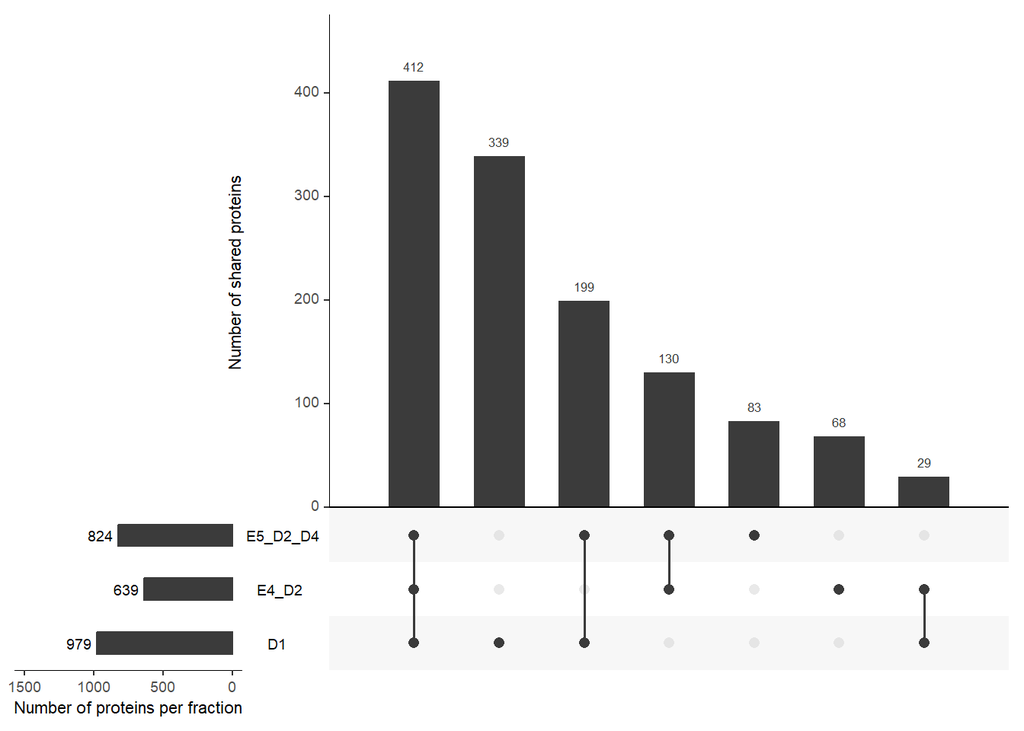

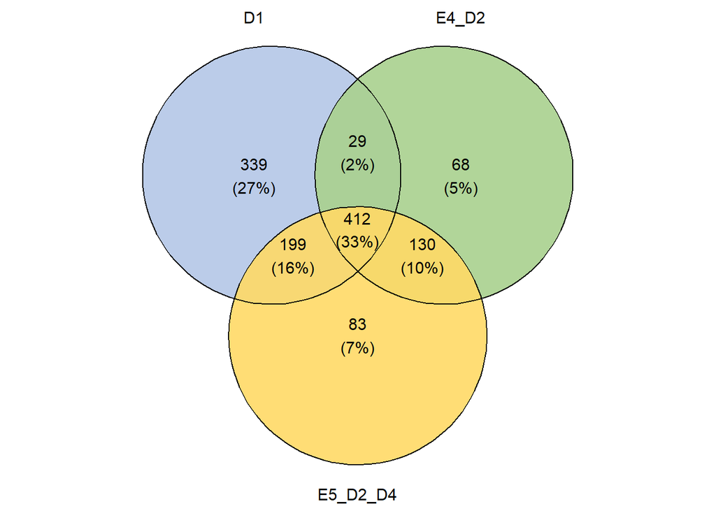

```r
ggvenn(lst,
       fill_color = c(IG,highMW,lowMW),
       stroke_size = 0.5, set_name_size = 4, text_size = 4, digits = 0, fill_alpha = 0.9)
```

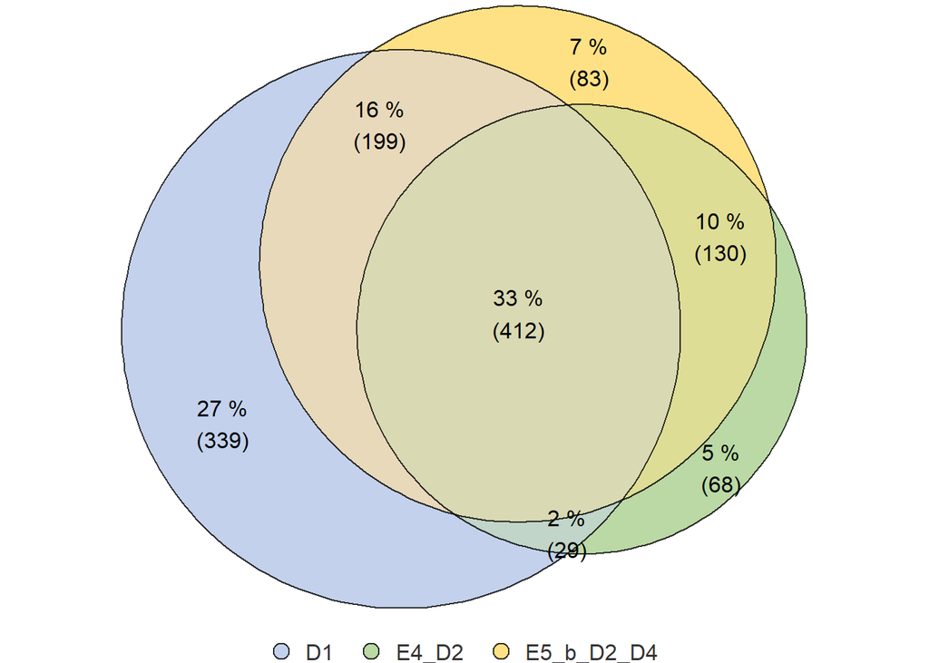

```r
euler_venn_3comp(lst, label_venn = c("D1","E4_D2","E5_b_D2_D4"), color_venn = c(IG,highMW,lowMW), cex_venn = c(1,1,1), h_just = 0.5, v_just = 0.5)
```

```r
print(c("D1","E4_D2","E5_D2_D4"))
```

```
## [1] "D1"       "E4_D2"    "E5_D2_D4"
```

```r
sum(comparison$D1,na.rm = TRUE)
```

```
## [1] 979
```

```r
sum(comparison$E4_D2,na.rm = TRUE)
```

```
## [1] 639
```

```r
sum(comparison$E5_D2_D4,na.rm = TRUE)
```

```
## [1] 824
```

## 12.2 Step2 merge(E3_e_f, E4_D1 a-j, E5_a, E5_b) mit E4_D2 E5_D2_D4

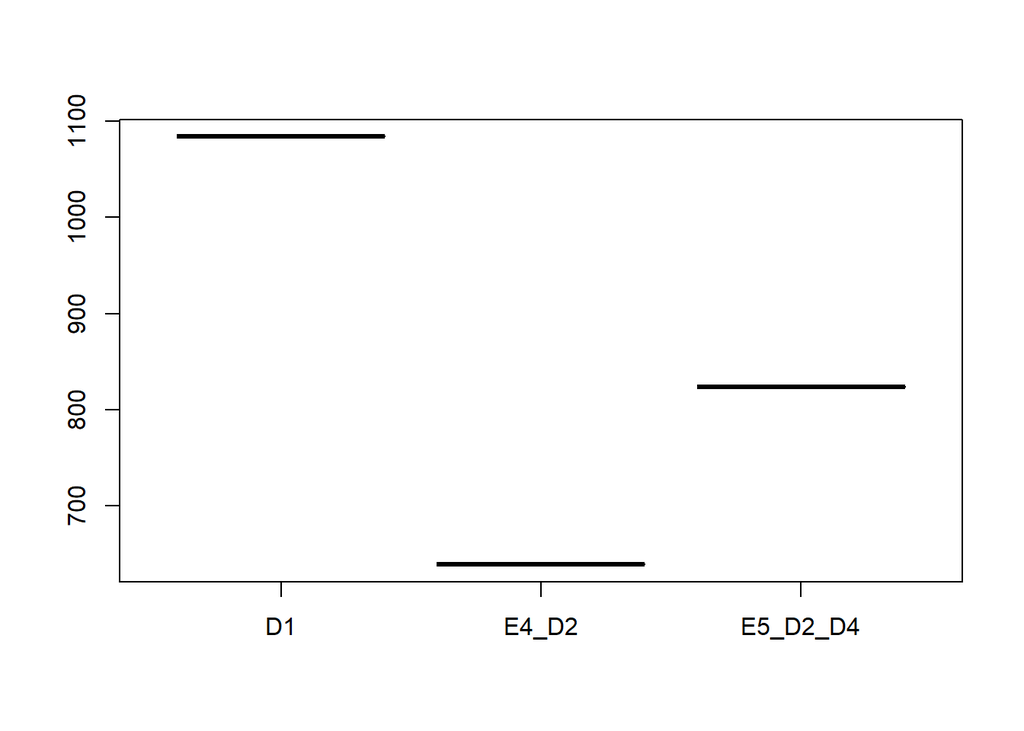

```r
aj_raw <- readRDS(file = "results_v002/results_run1_mqpar_extracts_2gether_E4_D1_a-j_LFQ_combined_txt_proteinGroups.txt_Unique.RDS")
aj_raw <- aj_raw[[1]]
aj <- aj_raw[,-ncol(aj_raw)]
FASTA <- c()
for (i in 1:length(aj_raw$FASTA)){
  tmp <- strsplit(aj_raw$FASTA[i],split='\\|')[[1]][2]
  FASTA<- c(FASTA,tmp)
}
aj <- cbind(aj,FASTA)

E3_D1_raw <- readRDS(file = "results_v002/results_run1_mqpar_extracts_2gether_E3_D1_LFQ_combined_txt_proteinGroups.txt_Unique.RDS")
E3_D1_raw <- E3_D1_raw[[1]]
E3_D1 <- E3_D1_raw[,c(13:18)]
FASTA <- c()
for (i in 1:length(E3_D1_raw$FASTA)){
  tmp <- strsplit(E3_D1_raw$FASTA[i],split='\\|')[[1]][2]
  FASTA<- c(FASTA,tmp)
}
E3_D1 <- cbind(E3_D1,FASTA)

E5_D1_raw <- readRDS(file="./27_20230201_FH/results/D5_extracts_Unique.RDS")
E5_D1_raw <- E5_D1_raw[[1]]
E5_D1 <- dplyr::select(E5_D1_raw, contains(".1"))
colnames(E5_D1) <- c(paste("Unique.peptides.","E5_D",substring(colnames(E5_D1),17),sep=""))
FASTA <- c()
for (i in 1:length(E5_D1_raw$FASTA)){
  tmp <- strsplit(E5_D1_raw$FASTA[i],split='\\|')[[1]][2]
  FASTA<- c(FASTA,tmp)
}
E5_D1 <- cbind(E5_D1,FASTA)


comp  <- merge(aj, E3_D1,
               all = TRUE,
               by = "FASTA")
comp <- merge(comp, E5_D1,
              all=TRUE,
              by="FASTA")

comp_D1 <- as.data.frame(cbind(comp$FASTA,apply(comp[,-1], 1, any)))
colnames(comp_D1) <- c("fasta","D1")

# E4-D2 comparison
D2_raw <- readRDS(file = "results_v002/results_run1_mqpar_extracts_2gether_D2_LFQ_combined_txt_proteinGroups.txt_Unique.RDS")
D2_raw <- D2_raw[[1]]
D2 <- dplyr::select(D2_raw, contains("Gesamt"))
D2 <- apply(D2, 1, any)
fasta <- c()
for (i in 1:length(D2_raw$FASTA)){
  tmp <- strsplit(D2_raw$FASTA[i],split='\\|')[[1]][2]
  fasta <- c(fasta,tmp)
}
#D2 <- as.data.frame(cbind(D2, D2_raw$FASTA))
D2 <- as.data.frame(cbind(D2, fasta))
# E5-D2
data <- readRDS("./27_20230201_FH/results/D5_extracts_Razor.RDS")
data <- data[[1]]
b <- dplyr::select(data, contains("2_b"))
b <- as.data.frame(apply(b, 1, any))
fasta <- c()
for (i in 1:length(data$FASTA)){
  tmp <- strsplit(data$FASTA[i],split='\\|')[[1]][2]
  fasta <- c(fasta,tmp)
}
b$fasta <- fasta
colnames(b) <- c("b","fasta")
###merge E4_D2 pool with E5_D2
comparison  <- merge(D2,b,
                     all = TRUE,
                     by = "fasta")
colnames(comparison) <- c("fasta","E4_D2","E5_D2")


#E5_D4
data <- readRDS("./27_20230201_FH/results/D5_extracts_Razor.RDS")
data <- data[[1]]
b <- dplyr::select(data, contains("4_b"))
b <- as.data.frame(apply(b, 1, any))
fasta <- c()
for (i in 1:length(data$FASTA)){
  tmp <- strsplit(data$FASTA[i],split='\\|')[[1]][2]
  fasta <- c(fasta,tmp)
}
b$fasta <- fasta
colnames(b) <- c("b","fasta")

###merge E4_D2 poo&E5_D2 with E5_D4
comparison  <- merge(comparison,b,
                     all = TRUE,
                     by = "fasta")
colnames(comparison) <- c("fasta","E4_D2","E5_D2","E5_D4")

comparison$comb_E5 <- apply(comparison[,c(3:4)], 1, any)

comp_D2_E4_E5 <- as.data.frame(cbind(comparison$fasta,comparison$E4_D2,comparison$comb_E5))
colnames(comp_D2_E4_E5) <- c("fasta","E4_D2","E5_D2_D4")

comparison  <- merge(comp_D1,comp_D2_E4_E5,
                     all = TRUE,
                     by = "fasta")
comparison$D1 <- as.logical(comparison$D1)
comparison$E4_D2 <- as.logical(comparison$E4_D2)
comparison$E5_D2_D4 <- as.logical(comparison$E5_D2_D4)
comparison <- comparison[,-1]*1
comparison[comparison==0] <- NA

# boxplot
boxplot(sum(comparison$D1,na.rm = TRUE),
        sum(comparison$E4_D2,na.rm = TRUE),
        sum(comparison$E5_D2_D4,na.rm = TRUE),
        names = c("D1","E4_D2","E5_D2_D4"))
```

```r
proteins <- as.data.frame(which(!is.na(comparison), arr.ind=TRUE))

D1 <- proteins %>% dplyr::filter(col == 1)
E4_D2 <- proteins %>% dplyr::filter(col == 2)
E5_D2_D4 <- proteins %>% dplyr::filter(col == 3)


# combine to list
lst <- list("D1"=as.double(D1[,1]),
            "E4_D2"=as.double(E4_D2[,1]),
            "E5_D2_D4"=as.double(E5_D2_D4[,1]))

upset(fromList(lst),
      order.by = "freq",
      nsets = 10,
      nintersects = 15,
      keep.order = TRUE,
      sets=c("D1","E4_D2", "E5_D2_D4"),
      mainbar.y.label = "Number of shared proteins",
      sets.x.label = "Number of proteins per fraction",
      set_size.show = TRUE,
      set_size.angles = 0,
      set_size.scale_max = 1500
)
```

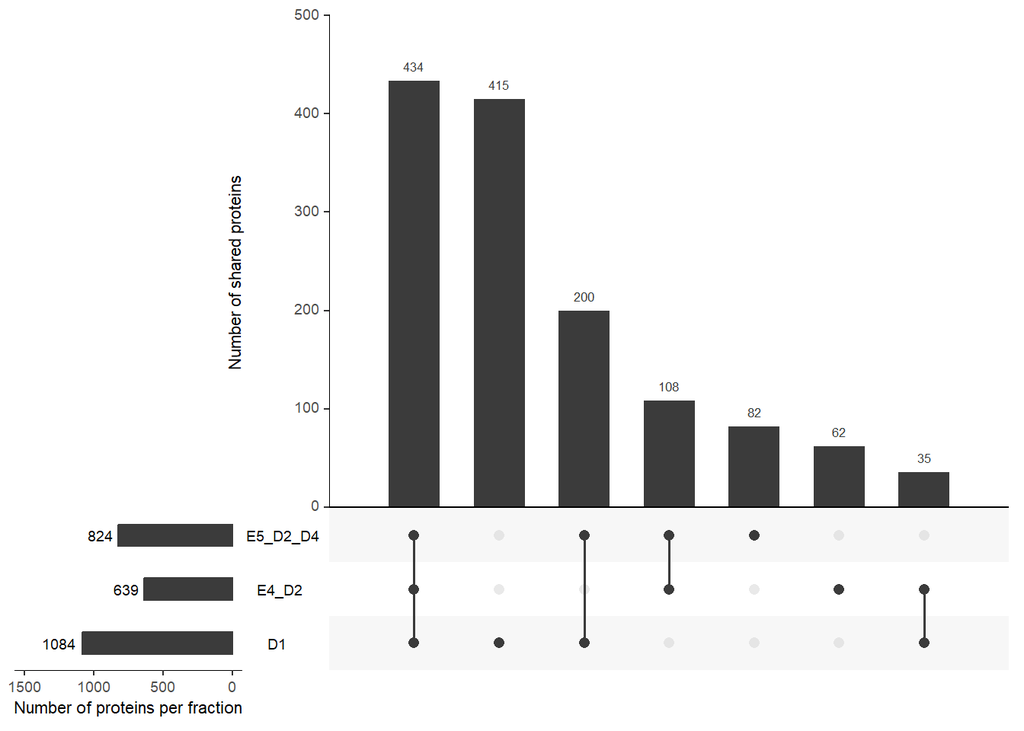

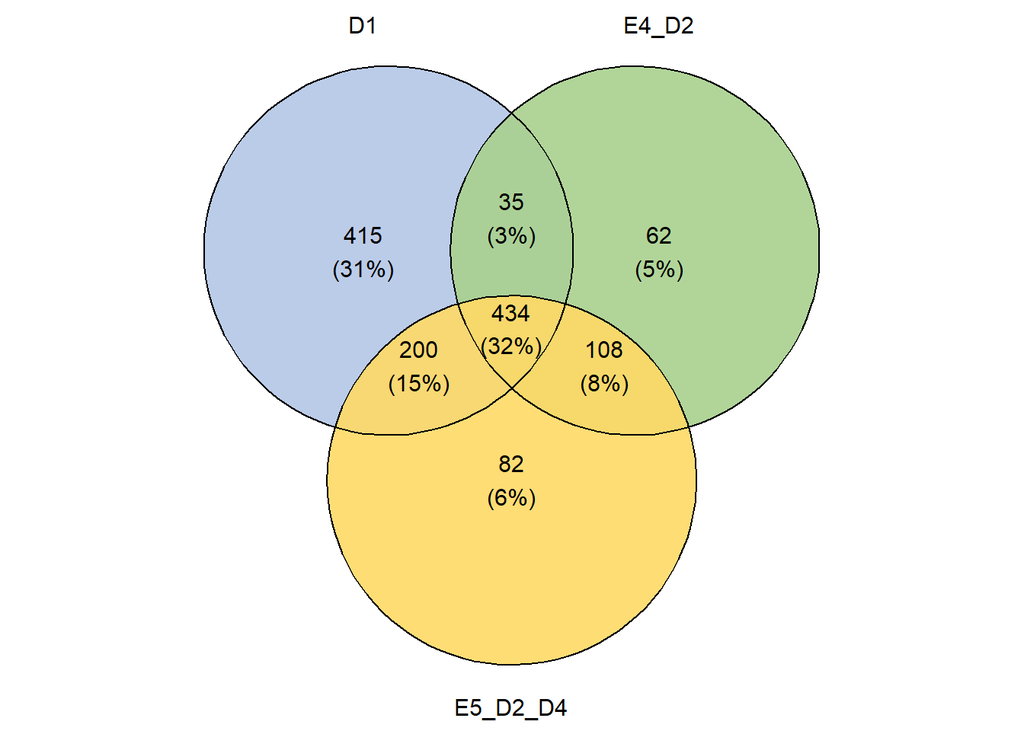

```r
ggvenn(lst,
       fill_color = c(IG,highMW,lowMW),
       stroke_size = 0.5, set_name_size = 4, text_size = 4, digits = 0, fill_alpha = 0.9)
```

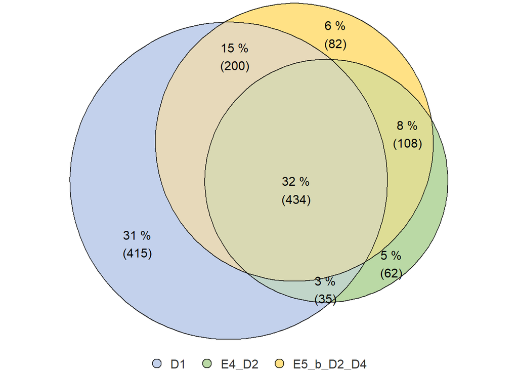

```r
euler_venn_3comp(lst, label_venn = c("D1","E4_D2","E5_b_D2_D4"), color_venn = c(IG,highMW,lowMW), cex_venn = c(1,1,1), h_just = 0.5, v_just = 0.5)
```

```r
print(c("D1","E4_D2","E5_D2_D4"))
```

```
## [1] "D1"       "E4_D2"    "E5_D2_D4"
```

```r
sum(comparison$D1,na.rm = TRUE)
```

```
## [1] 1084
```

```r
sum(comparison$E4_D2,na.rm = TRUE)
```

```
## [1] 639
```

```r
sum(comparison$E5_D2_D4,na.rm = TRUE)
```

```
## [1] 824
```

## 12.3 Step3 merge(E3_e_f, E4_D1 a-j, E5_a, E5_b) mit merge(E4_D2 E5_D2_D4)

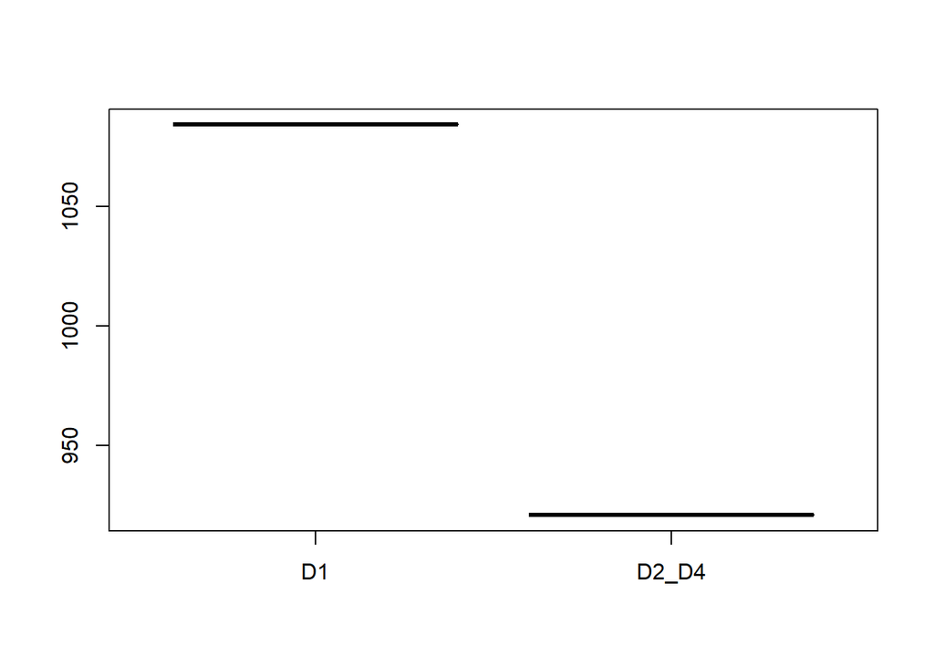

```r
aj_raw <- readRDS(file = "results_v002/results_run1_mqpar_extracts_2gether_E4_D1_a-j_LFQ_combined_txt_proteinGroups.txt_Unique.RDS")
aj_raw <- aj_raw[[1]]
aj <- aj_raw[,-ncol(aj_raw)]
FASTA <- c()
for (i in 1:length(aj_raw$FASTA)){
  tmp <- strsplit(aj_raw$FASTA[i],split='\\|')[[1]][2]
  FASTA<- c(FASTA,tmp)
}
aj <- cbind(aj,FASTA)

E3_D1_raw <- readRDS(file = "results_v002/results_run1_mqpar_extracts_2gether_E3_D1_LFQ_combined_txt_proteinGroups.txt_Unique.RDS")
E3_D1_raw <- E3_D1_raw[[1]]
E3_D1 <- E3_D1_raw[,c(13:18)]
FASTA <- c()
for (i in 1:length(E3_D1_raw$FASTA)){
  tmp <- strsplit(E3_D1_raw$FASTA[i],split='\\|')[[1]][2]
  FASTA<- c(FASTA,tmp)
}
E3_D1 <- cbind(E3_D1,FASTA)

E5_D1_raw <- readRDS(file="./27_20230201_FH/results/D5_extracts_Unique.RDS")
E5_D1_raw <- E5_D1_raw[[1]]
E5_D1 <- dplyr::select(E5_D1_raw, contains(".1"))
colnames(E5_D1) <- c(paste("Unique.peptides.","E5_D",substring(colnames(E5_D1),17),sep=""))
FASTA <- c()
for (i in 1:length(E5_D1_raw$FASTA)){
  tmp <- strsplit(E5_D1_raw$FASTA[i],split='\\|')[[1]][2]
  FASTA<- c(FASTA,tmp)
}
E5_D1 <- cbind(E5_D1,FASTA)


comp  <- merge(aj, E3_D1,
               all = TRUE,
               by = "FASTA")
comp <- merge(comp, E5_D1,
              all=TRUE,
              by="FASTA")

comp_D1 <- as.data.frame(cbind(comp$FASTA,apply(comp[,-1], 1, any)))
colnames(comp_D1) <- c("fasta","D1")

# E4-D2 comparison
D2_raw <- readRDS(file = "results_v002/results_run1_mqpar_extracts_2gether_D2_LFQ_combined_txt_proteinGroups.txt_Unique.RDS")
D2_raw <- D2_raw[[1]]
D2 <- dplyr::select(D2_raw, contains("Gesamt"))
D2 <- apply(D2, 1, any)
fasta <- c()
for (i in 1:length(D2_raw$FASTA)){
  tmp <- strsplit(D2_raw$FASTA[i],split='\\|')[[1]][2]
  fasta <- c(fasta,tmp)
}
#D2 <- as.data.frame(cbind(D2, D2_raw$FASTA))
D2 <- as.data.frame(cbind(D2, fasta))
# E5-D2
data <- readRDS("./27_20230201_FH/results/D5_extracts_Razor.RDS")
data <- data[[1]]
b <- dplyr::select(data, contains("2_b"))
b <- as.data.frame(apply(b, 1, any))
fasta <- c()
for (i in 1:length(data$FASTA)){
  tmp <- strsplit(data$FASTA[i],split='\\|')[[1]][2]
  fasta <- c(fasta,tmp)
}
b$fasta <- fasta
colnames(b) <- c("b","fasta")
###merge E4_D2 pool with E5_D2
comparison  <- merge(D2,b,
                     all = TRUE,
                     by = "fasta")
colnames(comparison) <- c("fasta","E4_D2","E5_D2")


#E5_D4
data <- readRDS("./27_20230201_FH/results/D5_extracts_Razor.RDS")
data <- data[[1]]
b <- dplyr::select(data, contains("4_b"))
b <- as.data.frame(apply(b, 1, any))
fasta <- c()
for (i in 1:length(data$FASTA)){
  tmp <- strsplit(data$FASTA[i],split='\\|')[[1]][2]
  fasta <- c(fasta,tmp)
}
b$fasta <- fasta
colnames(b) <- c("b","fasta")

###merge E4_D2 poo&E5_D2 with E5_D4
comparison  <- merge(comparison,b,
                     all = TRUE,
                     by = "fasta")
colnames(comparison) <- c("fasta","E4_D2","E5_D2","E5_D4")

comparison$comb_E5 <- apply(comparison[,c(3:4)], 1, any)

comp_D2_E4_E5 <- as.data.frame(cbind(comparison$fasta,comparison$E4_D2,comparison$comb_E5))
colnames(comp_D2_E4_E5) <- c("fasta","E4_D2","E5_D2_D4")

comparison  <- merge(comp_D1,comp_D2_E4_E5,
                     all = TRUE,
                     by = "fasta")

comparison$D2_D4 <- apply(comparison[,c(3:4)], 1, any)

comparison$D1 <- as.logical(comparison$D1)
comparison$D2_D4 <- as.logical(comparison$D2_D4)
comparison <- comparison[,-c(1,3,4)]*1
comparison[comparison==0] <- NA

# boxplot
boxplot(sum(comparison$D1,na.rm = TRUE),
        sum(comparison$D2_D4,na.rm = TRUE),
        names = c("D1","D2_D4"))
```

```r
proteins <- as.data.frame(which(!is.na(comparison), arr.ind=TRUE))

D1 <- proteins %>% dplyr::filter(col == 1)
D2_D4 <- proteins %>% dplyr::filter(col == 2)


# combine to list
lst <- list("D1"=as.double(D1[,1]),
            "D2_D4"=as.double(D2_D4[,1]))

upset(fromList(lst),
      order.by = "freq",
      nsets = 10,
      nintersects = 15,
      keep.order = TRUE,
      sets=c("D1","D2_D4"),
      mainbar.y.label = "Number of shared proteins",
      sets.x.label = "Number of proteins per fraction",
      set_size.show = TRUE,
      set_size.angles = 0,
      set_size.scale_max = 1500
)
```

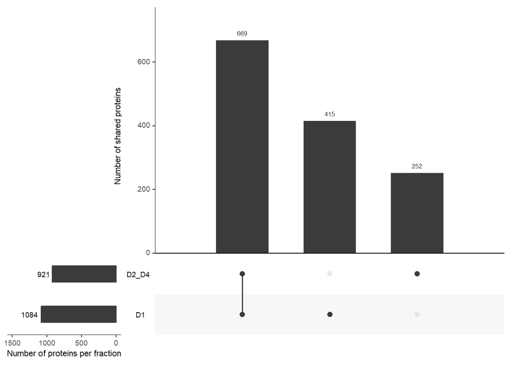

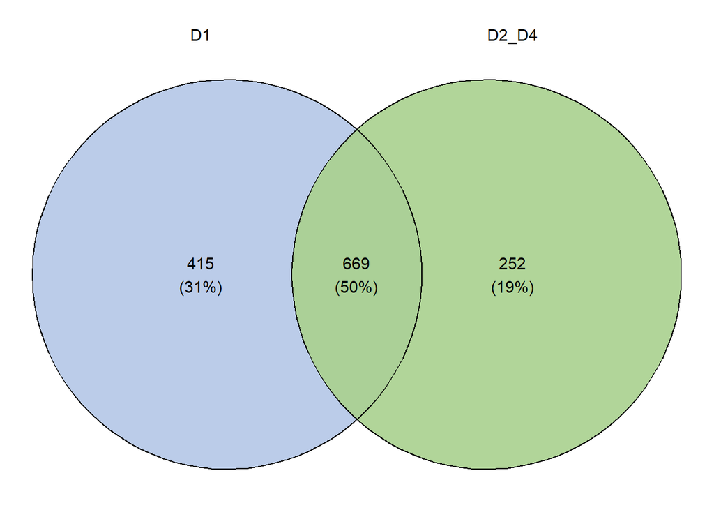

```r
ggvenn(lst,
       fill_color = c(IG,highMW,lowMW),
       stroke_size = 0.5, set_name_size = 4, text_size = 4, digits = 0, fill_alpha = 0.9)
```

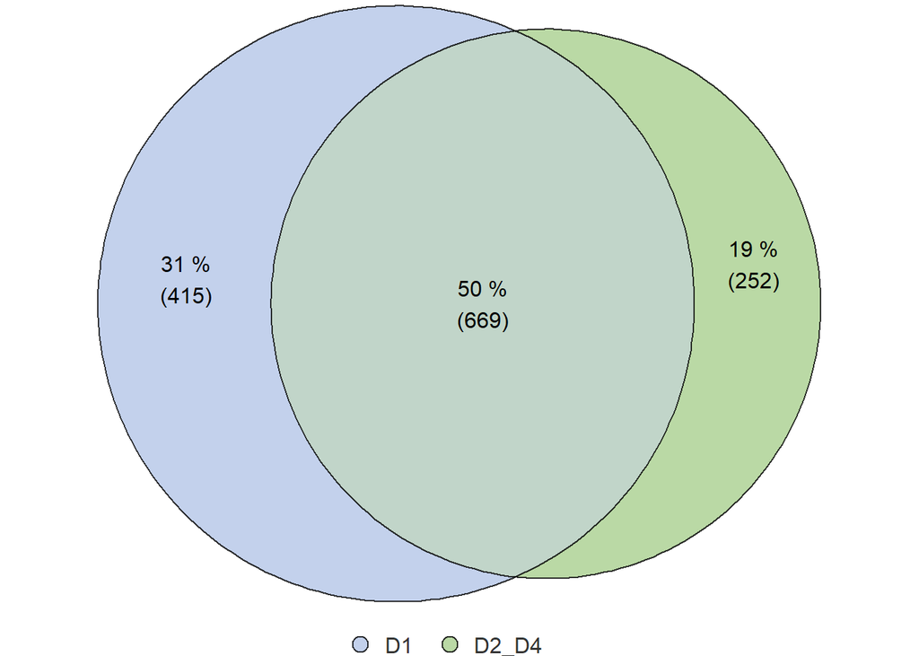

```r
euler_venn_3comp(lst, label_venn = c("D1","D2_D4"), color_venn = c(IG,highMW), cex_venn = c(1,1,1), h_just = 0.5, v_just = 0.5)
```

```r
print(c("D1","D2_D4"))
```

```
## [1] "D1"    "D2_D4"
```

```r
sum(comparison$D1,na.rm = TRUE)
```

```
## [1] 1084
```

```r
sum(comparison$D2_D4,na.rm = TRUE)
```

```
## [1] 921
```

# 13 Basic information

## 13.1 Auswertung Extrakte

- alle extrakte wurden am server ausgewertet (mqpar files: `/proj/proteomics/100_extracts_2gether/mqpar`)
- es wurden thematisch ähnliche extrakte gemeinsam ausgewertet (farblich hier markiert `\\fhwn.ac.at\TU\Forschung\wissenschaftliche Veröffentlichungen\Publikationen\2022\Proteomics_JRS_DL\data\Extraktionen_gesamt_V2_DL.xlsx`)
  - D2
  - E3_D1
  - E4_D1_AF_TF
  - E4_D1_a_j
  - E4_D1_B
  - E5 (liegt unter data/27_202301_FH)
- `X:\wissenschaftliche Veröffentlichungen\Publikationen\2022\Proteomics_JRS_DL\data\proteinGroups`: enthalten die proteinGroups.txt files die mit Razor/Unique ausgewertet wurden
- später wurde dann zum mqpar file auch LFQ hinzugefügt und neu ausgewertet; diese Ergebnisse werden auch fürs Paper verwendet und sind in `proteinGroups_v002` zu finden

### 13.1.1 Basic postprocessing

- die proteingroups.txt files wurden dann mit `basis-postprocessing.R`ausgewertet
- die Ergebnisse finden sich `results` bzw `results_v002`
  - es wurden RDS, csv und html files abgespeichert
  - diese Files wurden dann für die weitere Datenaufarbeitung verwendet
  - es wurden 2 pepitdes verwendet

### 13.1.2 MBR

- die Prozessierung erfolgte 1x ohne und 1x mit MBR
- zb `X:/wissenschaftliche Veröffentlichungen/Publikationen/2022/Proteomics_JRS_DL/data/results_v002`
  - `results_run1_mqpar_extracts_2gether_D2_LFQ_combined_txt_proteinGroups.txt_LFQ.RDS`: hier wurde D2 mit Unique/Razor/LFQ im xml file ausgewertet und die LFQ Ergebnisse abgespeichert
  - `results_run1_mqpar_extracts_2gether_D2_MBR_LFQ_combined_txt_proteinGroups.txt_LFQ.RDS`: das gleiche wie oben nur mit MBR im xml file
- als weiteres Beispiel für die Dateinamen
  - `results_run1_mqpar_extracts_2gether_D2_MBR_LFQ_combined_txt_proteinGroups.txt_Razor.RDS`: hier wurde D2 mit Unique/Razor/LFQ ausgewertet und die Razor Ergebnisse abgespeichert

### 13.1.3 files im results_v002 ordner

- hier sind die Ergebnisse der LFQ, Razor und Unique als RDS datei abgespeichert die dann für weitere Auswertungen verwendet werden
- zusätzlich sind die html files die automatisch generiert wurden dabie
- die csv datei enthält die gesamtidentifizierten/Quantifzierten proteine

## 13.2 TA/YEAST

- folder `X:\wissenschaftliche Veröffentlichungen\Publikationen\2022\Proteomics_JRS_DL\data\ta_yeast`
- die Mehlwürmer wurden in Weizenmehl/Hefeextrakt gezüchtet
- hier wurde getestet ob in den Extrakten auch Weizenproteine/Hefeproteine gefunden werden
- zusätzlich wurde gegen Rattenproteine bzw A.thaliana proteine gesucht um zu sehen ob komplett fremde organismenproteine gefunden werden können
- genommen wurden die mqpar files zur erzeugugn von proteinGroups, also ohne LFQ und nur Razor/Unique
- Ergebnisfile/Zusammenfassungfile: summary-ta-yeast.Rmd
  - es zeigt sich, dass sowohol Weizen/Hefe als auch Ratten- und a thaliana Proteine gefunden werden können
  - Ausmaß max. 8% der Gesamtproteine

## 13.3 evaluation_proteinmasses.html

- hier wurden die Proteinmassen von B1-B9 E4_D1_B bzw E4_D2 automatisch von uniprot herunterladen und visualisert um zu sehen ob sich die proteinmassen je fraktion unterschdein -> conlusio: gerade in den ersten fraktionen ziemlich gleiche masse; erst gegen ende werden die proteine merklich kleiner
- weiters wurden die Massen der geteilten Proteine in E4_D1_B angeschaut
  - das waren ca. 70 Proteine die in allen Fraktionen (B1-B9) vorgekommen sind

## 13.4 files evaluation summary …

- hier wurden die RDS files kombiniert eingelesen und mit den verschiedenen parametern diagramme erstellt um versch. einstellungen während der prozessierung in maxquant zu vergleichen
  - zb wurden Unique/Razor/LFQ mit MBR und ohne MBR verglichen zb `file:///X:/wissenschaftliche%20Ver%C3%B6ffentlichungen/Publikationen/2022/Proteomics_JRS_DL/data/evaluation_summary_unique.html` bzw. `file:///X:/wissenschaftliche%20Ver%C3%B6ffentlichungen/Publikationen/2022/Proteomics_JRS_DL/data/evaluation_summary_MBR_unique.html`
  - zusätzlich wurden noch versch imputation methods ausprobiert^`file:///X:/wissenschaftliche%20Ver%C3%B6ffentlichungen/Publikationen/2022/Proteomics_JRS_DL/data/evaluation_summary_unique_imputed_2consecutivevalues.html` oder `file:///X:/wissenschaftliche%20Ver%C3%B6ffentlichungen/Publikationen/2022/Proteomics_JRS_DL/data/evaluation_summary_unique_imputed.html`
- die zusammengefassten ergebnisse finden sich hier
  - `file:///X:/wissenschaftliche%20Ver%C3%B6ffentlichungen/Publikationen/2022/Proteomics_JRS_DL/data/evaluation_summary.html`

## 13.5 merging of 2 data sets

- bei der auswertung mussten teilweise datensätze gemerged werden
- zb wenn D2 und D1 verglichen werden sollen, wurden D1 und D2 ja in MaxQuant separat ausgewertet weswegen es 2 proteinGroupstxt files und auch ergebnisfiles (RDS files) gibt
- zum mergen wurde die spalte `fasta.headers` des proteingroups txt files verwendet
- im 1. Schritt wurde der gesamte text dieser spalte verwendet
- im 2. und hier dargestellten schritte wurde die accession number des ersten proteins der jeweiligen protein group mit folgendem code extrahiert und zum mergen verwendet

```
fasta <- c()
for (i in 1:length(AF_TF_raw$FASTA)){
  tmp <- strsplit(AF_TF_raw$FASTA[i],split='\\|')[[1]][2]
  fasta <- c(fasta,tmp)
}
```